# Coding Cookbook

Introductory Statistics (MA382)

This document provides a list of the code most commonly used in the course. There may be times, especially when working on an independent capstone project, when you want to move beyond what is discussed in class. There are many resources available online, or feel free to ask for guidance from the instructor. However, the majority of code needed for the course is documented here.

Throughout this document, we will be making use of the `mtcars` dataset available with all R installations. More information can be found about the variables in this dataset by typing `?mtcars` into your R console or typing `mtcars` into the help search box in RStudio. Here are the first few records of the dataset:

|  | mpg | cyl | disp | hp | drat | wt | qsec | vs | am | gear | carb |
| --- | --- | --- | --- | --- | --- | --- | --- | --- | --- | --- | --- |
| Mazda RX4 | 21.0 | 6 | 160 | 110 | 3.90 | 2.620 | 16.46 | 0 | 1 | 4 | 4 |
| Mazda RX4 Wag | 21.0 | 6 | 160 | 110 | 3.90 | 2.875 | 17.02 | 0 | 1 | 4 | 4 |
| Datsun 710 | 22.8 | 4 | 108 | 93 | 3.85 | 2.320 | 18.61 | 1 | 1 | 4 | 1 |
| Hornet 4 Drive | 21.4 | 6 | 258 | 110 | 3.08 | 3.215 | 19.44 | 1 | 0 | 3 | 1 |
| Hornet Sportabout | 18.7 | 8 | 360 | 175 | 3.15 | 3.440 | 17.02 | 0 | 0 | 3 | 2 |
| Valiant | 18.1 | 6 | 225 | 105 | 2.76 | 3.460 | 20.22 | 1 | 0 | 3 | 1 |

As you progress through the following examples, remember that R is *case sensitive*.

# Basics

Before proceeding to the specific aspects of the course; let’s first talk about a few basics about programming in R.

## Packages

Throughout the course we will be using a standard suite of packages (additional functions which provide additional analytical capabilities). In order to ensure that you have all required functionality for the course, be sure that each RMarkdown file you write has the following block at the top, which should not be altered:

```r
reyes382:::ma382_setup()
```

## Anatomy of RMarkdown File

An RMarkdown file is comprised of two components: basic text and “code chunks” which perform the analysis. When the document is compiled (“knit”) the code is evaluated and the results added seamlessly into your document. This encourages a reproducible workflow (someone can recreate all your results should the data change).

Code blocks can be added using the “Insert” button at the top of the script window. Code blocks have the following form:

````
```{r}
Code goes here...
```
````

Notice that the code blocks always begin and end with the triple backticks (found on your keyboard in the upper-left-hand corner with the tilde).

## Anatomy of R Code

Most code chunks all look the same. Below is a very simple code chunk. Objects are “assigned” to an object using an equal sign (or arrow `<-`). The code essentially says that the thing on the left will contain anything generated on the right.

```r
# Comments (not evaluated) begin with a hashtag.
ObjectName <- code to generate results
```

> Just typing the name of an object prints that object out; that output, in turn, will appear in your final document.

If we want to do something to that object, we will make use of the “pipe operator” (`%>%`) which essentially says take the thing before and use it in the next function. For example, we might summarise an object as follows:

```r
ObjectTwo <- ObjectOne %>%
  summarise()
```

This code says take the thing called “ObjectOne” and “pipe it into” (use within) the summarise function; whatever the result of this operation is will be called “ObjectTwo.”

## Creating a Dataset from Scratch

Occasionally, you may need to input data manually (generally, data will be provided to you). This is done using the `tibble()` function. Things to keep in mind include

- Variables are separated by commas.
- Each variable must be named (`Variable_Name =`).
- Values are separated by commas and placed inside the `c()` function.
- Values of a categorical variable are placed inside quotes.

Here is a hypothetical example in which the results of a simple survey are entered into a dataset called `demographics`.

```r
demographics <- tibble(
  `Hair Color` = c("Black", "Black", "Brown", "Blonde", "Black"),
  Age = c(20, 19, 21, 20, 20)
)
```

## Reading a Dataset

Nearly all data will be given to you in the form of a CSV file. You can read such a file using the `read_csv()` function:

```r
my_data <- read_csv("Path-to-File.csv")
```

If the data exists in the same directory (folder) as your RMarkdown file, then “Path-to-File” can simply be the name of the file.

# Data Manipulation

- `mutate()`: manipulate variables or make transformations.
- `arrange()`: sort a dataset.
- `filter()`: subset the data based on some criteria.

## mutate(): creating or changing variables

As an example, while the US measures fuel efficiency in miles per gallon, other countries often report the gallons required for a single mile. This new variable `Gallons_per_Mile` can be created using `mutate()`:

```r
mtcars <- mtcars %>%
  mutate(Gallons_per_Mile = 1/mpg)
```

Notice that we use the pipe operator (`%>%`) here; this essentially says take the dataset `mtcars` and feed it into the `mutate()` function. The `mutate()` function itself uses the notation `New_Variable_Name = transformation of stuff`. In this case, we create a new variable within the dataset `mtcars`. The result is stored within a dataset called `mtcars` (since that is on the left of the equal sign), essentially overwriting the original dataset.

The first few records of this dataset are shown below:

|  | mpg | cyl | disp | hp | drat | wt | qsec | vs | am | gear | carb | Gallons_per_Mile |
| --- | --- | --- | --- | --- | --- | --- | --- | --- | --- | --- | --- | --- |
| Mazda RX4 | 21.0 | 6 | 160 | 110 | 3.90 | 2.620 | 16.46 | 0 | 1 | 4 | 4 | 0.048 |
| Mazda RX4 Wag | 21.0 | 6 | 160 | 110 | 3.90 | 2.875 | 17.02 | 0 | 1 | 4 | 4 | 0.048 |
| Datsun 710 | 22.8 | 4 | 108 | 93 | 3.85 | 2.320 | 18.61 | 1 | 1 | 4 | 1 | 0.044 |
| Hornet 4 Drive | 21.4 | 6 | 258 | 110 | 3.08 | 3.215 | 19.44 | 1 | 0 | 3 | 1 | 0.047 |
| Hornet Sportabout | 18.7 | 8 | 360 | 175 | 3.15 | 3.440 | 17.02 | 0 | 0 | 3 | 2 | 0.053 |
| Valiant | 18.1 | 6 | 225 | 105 | 2.76 | 3.460 | 20.22 | 1 | 0 | 3 | 1 | 0.055 |

## arrange(): order the data

To sort the data, consider ordering the `mtcars` dataset by the the number of cylinders the car has. This can be done using the `arrange()` function:

```r
mtcars <- mtcars %>%
  arrange(cyl)
```

The results are stored in the `mtcars` dataset (the first few records of which are shown below).

|  | mpg | cyl | disp | hp | drat | wt | qsec | vs | am | gear | carb | Gallons_per_Mile |
| --- | --- | --- | --- | --- | --- | --- | --- | --- | --- | --- | --- | --- |
| Datsun 710 | 22.8 | 4 | 108.0 | 93 | 3.85 | 2.320 | 18.61 | 1 | 1 | 4 | 1 | 0.044 |
| Merc 240D | 24.4 | 4 | 146.7 | 62 | 3.69 | 3.190 | 20.00 | 1 | 0 | 4 | 2 | 0.041 |
| Merc 230 | 22.8 | 4 | 140.8 | 95 | 3.92 | 3.150 | 22.90 | 1 | 0 | 4 | 2 | 0.044 |
| Fiat 128 | 32.4 | 4 | 78.7 | 66 | 4.08 | 2.200 | 19.47 | 1 | 1 | 4 | 1 | 0.031 |
| Honda Civic | 30.4 | 4 | 75.7 | 52 | 4.93 | 1.615 | 18.52 | 1 | 1 | 4 | 2 | 0.033 |
| Toyota Corolla | 33.9 | 4 | 71.1 | 65 | 4.22 | 1.835 | 19.90 | 1 | 1 | 4 | 1 | 0.029 |

## filter(): subsetting a variable

If we only want to look at a subset of the data, we use the `filter()` function. For example, suppose we only want to consider vehicles which have automatic transmissions. Further, we would like to store those in a new dataset called `automatic.only`, we use the following code:

```r
automatic.only <- mtcars %>%
  filter(am == 0)
```

When making comparisons, `==` is asking “are you equal?” We keep the records for which we would answer “yes” to this question. The original `mtcars` dataset is not altered; it remains unchanged. Instead, we have taken it, filtered it down, and then stored the results in `automatic.only` (the first few records of which are shown below).

|  | mpg | cyl | disp | hp | drat | wt | qsec | vs | am | gear | carb | Gallons_per_Mile |
| --- | --- | --- | --- | --- | --- | --- | --- | --- | --- | --- | --- | --- |
| Merc 240D | 24.4 | 4 | 146.7 | 62 | 3.69 | 3.190 | 20.00 | 1 | 0 | 4 | 2 | 0.041 |
| Merc 230 | 22.8 | 4 | 140.8 | 95 | 3.92 | 3.150 | 22.90 | 1 | 0 | 4 | 2 | 0.044 |
| Toyota Corona | 21.5 | 4 | 120.1 | 97 | 3.70 | 2.465 | 20.01 | 1 | 0 | 3 | 1 | 0.047 |
| Hornet 4 Drive | 21.4 | 6 | 258.0 | 110 | 3.08 | 3.215 | 19.44 | 1 | 0 | 3 | 1 | 0.047 |
| Valiant | 18.1 | 6 | 225.0 | 105 | 2.76 | 3.460 | 20.22 | 1 | 0 | 3 | 1 | 0.055 |
| Merc 280 | 19.2 | 6 | 167.6 | 123 | 3.92 | 3.440 | 18.30 | 1 | 0 | 4 | 4 | 0.052 |

Below is a table of common comparisons:

| Comparison | Code |
| --- | --- |
| Equality | `==` |
| Less Than | `<` |
| Greater Than | `>` |
| Less Than or Equal To | `<=` |
| Greater Than or Equal To | `>=` |
| Not Equal | `!=` |

## recode(): Changing the values of a variable

When we work with categorical variables, we often want the values (or group labels) to be something readable. In order to do this, we may need to recode the data. Consider the variable `am` (transmission type). It is currently a 0/1 variable, and it is not obvious that 1 represents manual transmission and 0 automatic transmission. We can make this clearer by mutating the dataset and recoding that variable.

```r
mtcars <- mtcars %>%
  mutate(am = recode(am,
                     `0` = "automatic",
                     `1` = "manual"))
```

|  | mpg | cyl | disp | hp | drat | wt | qsec | vs | am | gear | carb | Gallons_per_Mile |
| --- | --- | --- | --- | --- | --- | --- | --- | --- | --- | --- | --- | --- |
| Datsun 710 | 22.8 | 4 | 108.0 | 93 | 3.85 | 2.320 | 18.61 | 1 | manual | 4 | 1 | 0.044 |
| Merc 240D | 24.4 | 4 | 146.7 | 62 | 3.69 | 3.190 | 20.00 | 1 | automatic | 4 | 2 | 0.041 |
| Merc 230 | 22.8 | 4 | 140.8 | 95 | 3.92 | 3.150 | 22.90 | 1 | automatic | 4 | 2 | 0.044 |
| Fiat 128 | 32.4 | 4 | 78.7 | 66 | 4.08 | 2.200 | 19.47 | 1 | manual | 4 | 1 | 0.031 |
| Honda Civic | 30.4 | 4 | 75.7 | 52 | 4.93 | 1.615 | 18.52 | 1 | manual | 4 | 2 | 0.033 |
| Toyota Corolla | 33.9 | 4 | 71.1 | 65 | 4.22 | 1.835 | 19.90 | 1 | manual | 4 | 1 | 0.029 |

If we now wanted to go further and change “automatic” to “Automatic Transmission”, we could recode again; this time, since the variable is already a phrase, we do not use backticks.

```r
mtcars <- mtcars %>%
  mutate(am = recode(am,
                     "automatic" = "Automatic Transmission",
                     "manual" = "Manual Transmission"))
```

> If your dataset has groups coded as numbers (like above when 0 = automatic and 1 = manual), it is best to recode in order for graphics and models to work appropriately.

# Numerical Summaries

Numerical summaries (statistics) tell us about the distribution of our sample. These also estimate the corresponding parameters of interest in the population. We will primarily use the `skim_clean()` function to summarize all variables in a dataset.

The resulting output is divided up by the type of variables in the dataset. Categorical variables (“characters” and “factors” in R) are summarized differently (counts of each unique value) than numeric variables (mean, percentiles, etc.).

```r
skim_clean(mtcars)
```

Data summary

| Name | mtcars |
| --- | --- |
| Number of rows | 32 |
| Number of columns | 12 |
| _______________________ |  |
| Column type frequency: |  |
| character | 1 |
| numeric | 11 |
| ________________________ |  |
| Group variables | None |

**Variable type: character**

| skim_variable | n_missing | complete_rate | n_unique | counts | percs |
| --- | --- | --- | --- | --- | --- |
| am | 0 | 1 | 2 | Automatic Transmission:19, Manual Transmission:13 | Automatic Transmission:59.4, Manual Transmission:40.6 |

**Variable type: numeric**

| skim_variable | n_missing | complete_rate | mean | sd | p0 | p25 | p50 | p75 | p100 |
| --- | --- | --- | --- | --- | --- | --- | --- | --- | --- |
| mpg | 0 | 1 | 20.09 | 6.03 | 10.40 | 15.43 | 19.20 | 22.80 | 33.90 |
| cyl | 0 | 1 | 6.19 | 1.79 | 4.00 | 4.00 | 6.00 | 8.00 | 8.00 |
| disp | 0 | 1 | 230.72 | 123.94 | 71.10 | 120.83 | 196.30 | 326.00 | 472.00 |
| hp | 0 | 1 | 146.69 | 68.56 | 52.00 | 96.50 | 123.00 | 180.00 | 335.00 |
| drat | 0 | 1 | 3.60 | 0.53 | 2.76 | 3.08 | 3.70 | 3.92 | 4.93 |
| wt | 0 | 1 | 3.22 | 0.98 | 1.51 | 2.58 | 3.33 | 3.61 | 5.42 |
| qsec | 0 | 1 | 17.85 | 1.79 | 14.50 | 16.89 | 17.71 | 18.90 | 22.90 |
| vs | 0 | 1 | 0.44 | 0.50 | 0.00 | 0.00 | 0.00 | 1.00 | 1.00 |
| gear | 0 | 1 | 3.69 | 0.74 | 3.00 | 3.00 | 4.00 | 4.00 | 5.00 |
| carb | 0 | 1 | 2.81 | 1.62 | 1.00 | 2.00 | 2.00 | 4.00 | 8.00 |
| Gallons_per_Mile | 0 | 1 | 0.05 | 0.02 | 0.03 | 0.04 | 0.05 | 0.06 | 0.10 |

If you want to create summaries for different subsets of the data, you can first “group” the data using the `group_by()` function. Notice that the summaries of each variable are then computed within each group.

```r
mtcars %>%
  group_by(am) %>%
  skim_clean()
```

Data summary

| Name | Piped data |
| --- | --- |
| Number of rows | 32 |
| Number of columns | 12 |
| _______________________ |  |
| Column type frequency: |  |
| numeric | 11 |
| ________________________ |  |
| Group variables | am |

**Variable type: numeric**

| skim_variable | am | n_missing | complete_rate | mean | sd | p0 | p25 | p50 | p75 | p100 |
| --- | --- | --- | --- | --- | --- | --- | --- | --- | --- | --- |
| mpg | Automatic Transmission | 0 | 1 | 17.15 | 3.83 | 10.40 | 14.95 | 17.30 | 19.20 | 24.40 |
| mpg | Manual Transmission | 0 | 1 | 24.39 | 6.17 | 15.00 | 21.00 | 22.80 | 30.40 | 33.90 |
| cyl | Automatic Transmission | 0 | 1 | 6.95 | 1.54 | 4.00 | 6.00 | 8.00 | 8.00 | 8.00 |
| cyl | Manual Transmission | 0 | 1 | 5.08 | 1.55 | 4.00 | 4.00 | 4.00 | 6.00 | 8.00 |
| disp | Automatic Transmission | 0 | 1 | 290.38 | 110.17 | 120.10 | 196.30 | 275.80 | 360.00 | 472.00 |
| disp | Manual Transmission | 0 | 1 | 143.53 | 87.20 | 71.10 | 79.00 | 120.30 | 160.00 | 351.00 |
| hp | Automatic Transmission | 0 | 1 | 160.26 | 53.91 | 62.00 | 116.50 | 175.00 | 192.50 | 245.00 |
| hp | Manual Transmission | 0 | 1 | 126.85 | 84.06 | 52.00 | 66.00 | 109.00 | 113.00 | 335.00 |
| drat | Automatic Transmission | 0 | 1 | 3.29 | 0.39 | 2.76 | 3.07 | 3.15 | 3.70 | 3.92 |
| drat | Manual Transmission | 0 | 1 | 4.05 | 0.36 | 3.54 | 3.85 | 4.08 | 4.22 | 4.93 |
| wt | Automatic Transmission | 0 | 1 | 3.77 | 0.78 | 2.46 | 3.44 | 3.52 | 3.84 | 5.42 |
| wt | Manual Transmission | 0 | 1 | 2.41 | 0.62 | 1.51 | 1.94 | 2.32 | 2.78 | 3.57 |
| qsec | Automatic Transmission | 0 | 1 | 18.18 | 1.75 | 15.41 | 17.18 | 17.82 | 19.17 | 22.90 |
| qsec | Manual Transmission | 0 | 1 | 17.36 | 1.79 | 14.50 | 16.46 | 17.02 | 18.61 | 19.90 |
| vs | Automatic Transmission | 0 | 1 | 0.37 | 0.50 | 0.00 | 0.00 | 0.00 | 1.00 | 1.00 |
| vs | Manual Transmission | 0 | 1 | 0.54 | 0.52 | 0.00 | 0.00 | 1.00 | 1.00 | 1.00 |
| gear | Automatic Transmission | 0 | 1 | 3.21 | 0.42 | 3.00 | 3.00 | 3.00 | 3.00 | 4.00 |
| gear | Manual Transmission | 0 | 1 | 4.38 | 0.51 | 4.00 | 4.00 | 4.00 | 5.00 | 5.00 |
| carb | Automatic Transmission | 0 | 1 | 2.74 | 1.15 | 1.00 | 2.00 | 3.00 | 4.00 | 4.00 |
| carb | Manual Transmission | 0 | 1 | 2.92 | 2.18 | 1.00 | 1.00 | 2.00 | 4.00 | 8.00 |
| Gallons_per_Mile | Automatic Transmission | 0 | 1 | 0.06 | 0.02 | 0.04 | 0.05 | 0.06 | 0.07 | 0.10 |
| Gallons_per_Mile | Manual Transmission | 0 | 1 | 0.04 | 0.01 | 0.03 | 0.03 | 0.04 | 0.05 | 0.07 |

## Specific Summaries

The `skim_clean()` function above summarizes all variables in a dataset. However, we may wish to obtain only a subset of specifc numerical summaries. This can be accomplished using the `summarise()` function. For example, the code

```r
mtcars %>%
  summarise(Mean_MPG = mean(mpg), SD_MPG = sd(mpg))
```

```
  Mean_MPG   SD_MPG
1 20.09062 6.026948
```

The `summarise()` function takes a series of `Name = operation` statements, separated by commas. The left-hand side is the name of the column in the output, and the right-hand side is the code for computing the summary. Below is a table of functions for common summaries:

| Operation | Function |
| --- | --- |
| Sample Mean | `mean()` |
| Sample Standard Deviation | `sd()` |
| Sample Variance | `var()` |
| Sample Median | `median()` |
| Interquartile Range | `IQR()` |
| k-th Quantile | `quantile(x, probs = c(k))` |
| Sample Maximum | `max()` |
| Sample Minimum | `min()` |
| Sample Size | `length()` |

## Extracting a Specific Variable

Often, our summaries should remain in a dataset themselves for future use; that is the purpose of `summarise()`. There may be times when you want to extract a variable from a dataset to have the result separate. This can be accomplished using the `$` operator. The following code computes the sample mean of the MPG. Instead of returning a dataset with the result inside, it simply computes the values and stores it as a result.

```r
mean(mtcars$mpg)
```

```
[1] 20.09062
```

# Graphics

A picture is worth 1000 words. A good graphical summary of the data should not only be a first step in an analysis, but it should also accompany any good analysis to help convey the message of the data. All graphics in this class will be produced with the `ggplot()` function. If you are interested in moving beyond what is described here, I would encourage you to look at the `ggplot2` package and would guide you toward the [Ggplot Cheat Sheet](https://www.rstudio.com/wp-content/uploads/2015/03/ggplot2-cheatsheet.pdf).

The `ggplot()` function has a couple of basic components:

- `data =` specifies the data set in which the variables exist.
- `mapping = aes()` specifies how variables are mapped to different axes.

The various axes are

- `y =` the variable on the y-axis
- `x =` the variable on the x-axis
- `color =` the variable defining various color groupings
- `shape =` the variable defining shape groupings
- `size =` the variable defining the size groupings
- `fill =` the variable defining the fill groupings
- `group =` the variable defining a unique group (this is often omitted and determined by the remaining axes)

Of course, just determining on which axis each variable is placed does not create a graphic. You need to place the data on the plot in some way. This is done by adding a “layer.” Each layer creates a different type of graphic. Some of the more common are summarized here:

- `geom_histogram()` creates a histogram
- `geom_boxplot()` creates a boxplot
- `geom_point()` places individual points on the graph (scatterplot)
- `geom_line()` connects the values with lines
- `geom_jitter()` places points on the plot and then moves them horizontally or vertically at random to avoid overplotting
- `geom_violin()` creates violin plots
- `geom_density()` creates density plots

We also need to add labels to the graphic using the `labs()` function. As the examples below illustrate, labels are defined by the features set in the graphic command itself (`x`, `y`, `color`, etc.). We now discuss various ways of combining these settings to create common graphics.

Finally, occasionally, you do not want a legend to appear; you can remove the legend by using the `guides(name = "none")` command.

## Categorical Variable: Bar Chart

A bar chart is the simplest (and often best) method for summarizing the distribution of a categorical variable. The key steps to making a bar chart include:

1. Place the variable you want to summarize on the x-axis.
2. Use `geom_bar()`.
3. Note: nothing goes on the y-axis.

For example, we can summarize the number of vehicles with each type of transmission using the following code.

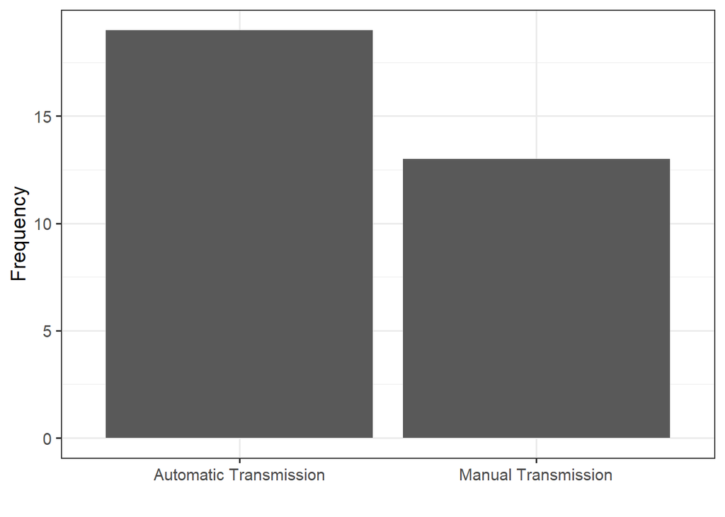

```r
ggplot(data = mtcars,
       mapping = aes(x = am)) +
  geom_bar() +
  labs(x = "",
       y = "Frequency")
```

We remove the label on the x-axis because the value of the variable makes it clear what is being summarized.

## Multiple Categorical Variables: Bar Charts

If you have multiple categorical variables, consider using additional aesthetics to group variables. We will consider a bar chart summarizing the type of engine and the type of transmission for each vehicle. First, we clean up the way that the variable `vs` is coded:

```r
mtcars <- mtcars %>%
  mutate(vs = recode(vs,
                     `0` = "V Engine",
                     `1` = "Straight Engine"))
```

Now, we construct the graphic using the following steps:

1. Place primary variable of interest on x-axis.
2. Use `fill =` to set the secondary variable.
3. Use `geom_bar()`.

Again, we remove the labels of both the `fill` and the `x` variables because the values are self-evident.

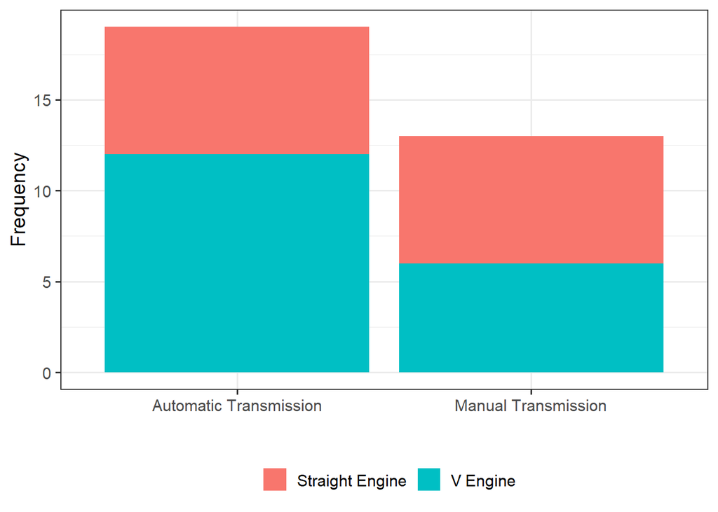

```r
ggplot(data = mtcars,
       mapping = aes(x = am, fill = vs)) +
  geom_bar() +
  labs(x = "",
       fill = "",
       y = "Frequency")
```

## Quantitative Variable: Histogram

When looking at the distribution of a single variable, a histogram is a reasonable choice, especially for medium-sized datasets.

1. Set the variable to summarize on the x-axis.
2. Choose `geom_histogram()`.
3. Set the `binwidth =` option to a reasonable size (how large do you want each bin to be). This changes for each problem and is a matter of opinion on what gives a reasonable looking graphic.

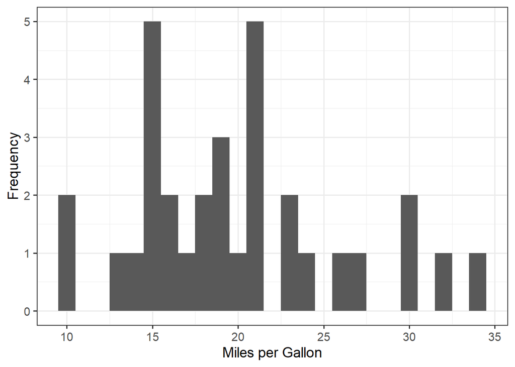

```r
ggplot(data = mtcars,
       mapping = aes(x = mpg)) +
  geom_histogram(binwidth = 1) +
  labs(x = "Miles per Gallon",
       y = "Frequency")
```

In this graphic, we set the binwidth to be 1. We could also have considered a larger binwidth of 3, for example:

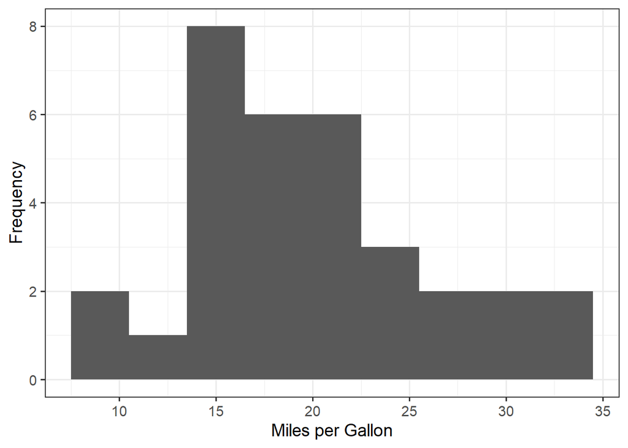

```r
ggplot(data = mtcars,
       mapping = aes(x = mpg)) +
  geom_histogram(binwidth = 3) +
  labs(x = "Miles per Gallon",
       y = "Frequency")
```

If you exclude the `binwidth =` option, it will choose a value for you:

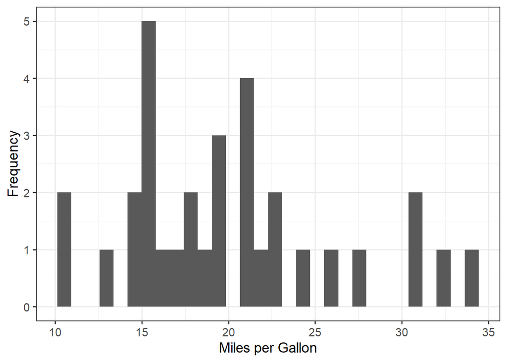

```r
ggplot(data = mtcars,
       mapping = aes(x = mpg)) +
  geom_histogram() +
  labs(x = "Miles per Gallon",
       y = "Frequency")
```

## Quantitative Variable: Density

A density plot is like a smooth histogram; this works best with larger datasets.

1. Set the variable to summarize on the x-axis.
2. Choose `geom_density()`

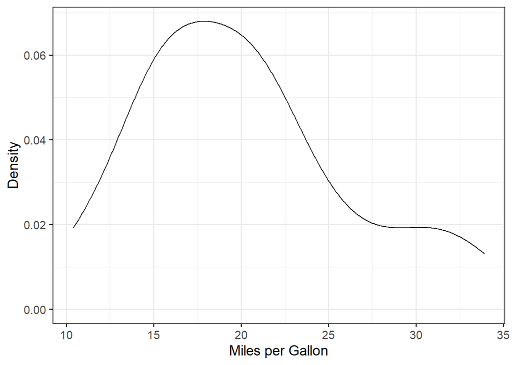

```r
ggplot(data = mtcars,
       mapping = aes(x = mpg)) +
  geom_density() +
  labs(x = "Miles per Gallon",
       y = "Density")
```

The y-axis on this graphic is not directly interpretable; essentially they have been chosen such that the area under the curve is equal to 1. Our primary interest here is that larger values mean the values on the x-axis are more likely.

## Quantitative Variable: Boxplot

A boxplot gives a quick summary of location and spread for a numeric variable.

1. Set the variable to summarize on the y-axis.
2. Set the x-axis to be empty: "".
3. Choose `geom_boxplot()`

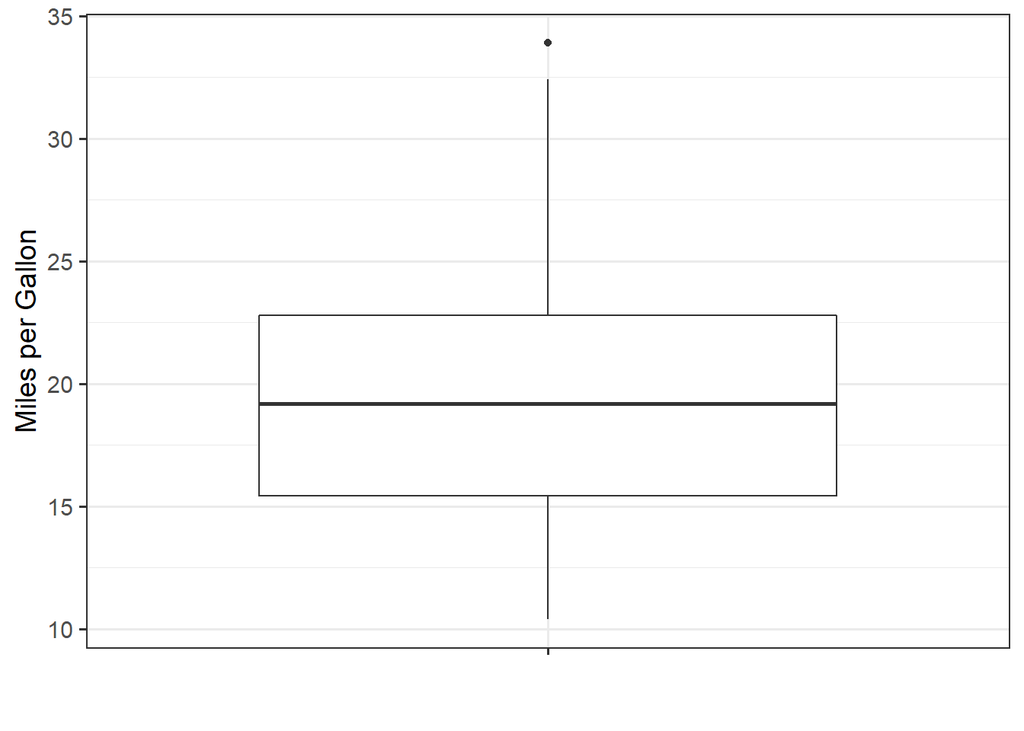

```r
ggplot(data = mtcars,
       mapping = aes(y = mpg, x = "")) +
  geom_boxplot() +
  labs(y = "Miles per Gallon",
       x = "")
```

## Quantitative Variable Across Groups: Boxplots

If we are examining the distribution of a quantitative variable across various groups formed by a categorical variable, we can use side-by-side graphics, such as boxplots.

1. Set the variable to be summarized on the y-axis.
2. Place the grouping variable on the x-axis.
3. Set `geom_boxplot()`.

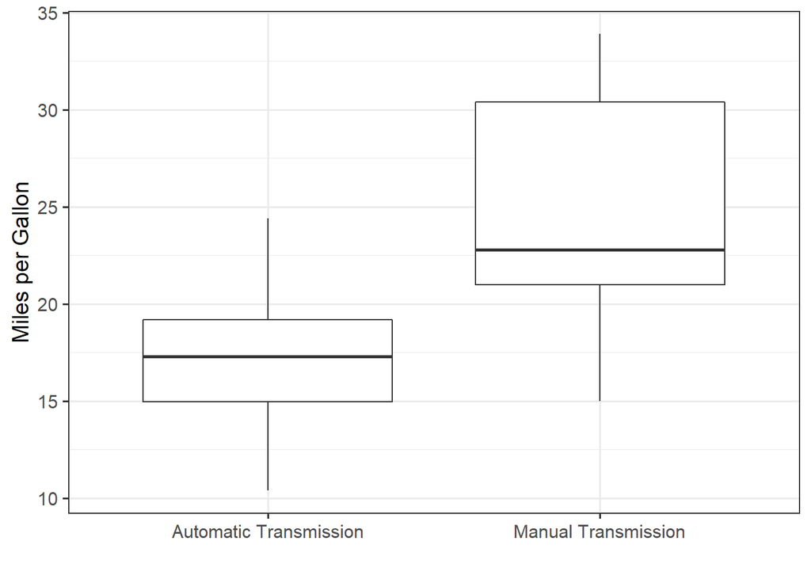

```r
ggplot(data = mtcars,
       mapping = aes(y = mpg, x = am)) +
  geom_boxplot() +
  labs(y = "Miles per Gallon",
       x = "")
```

## Quantitative Variable Across Groups: Violin Plots

Boxplots summarize the center and spread of the data, but the shape is lost. Violin plots generalize boxplots by incorporating the shape.

1. Set the variable to be summarized on the y-axis.
2. Place the grouping variable on the x-axis.
3. Set `geom_violin()`.

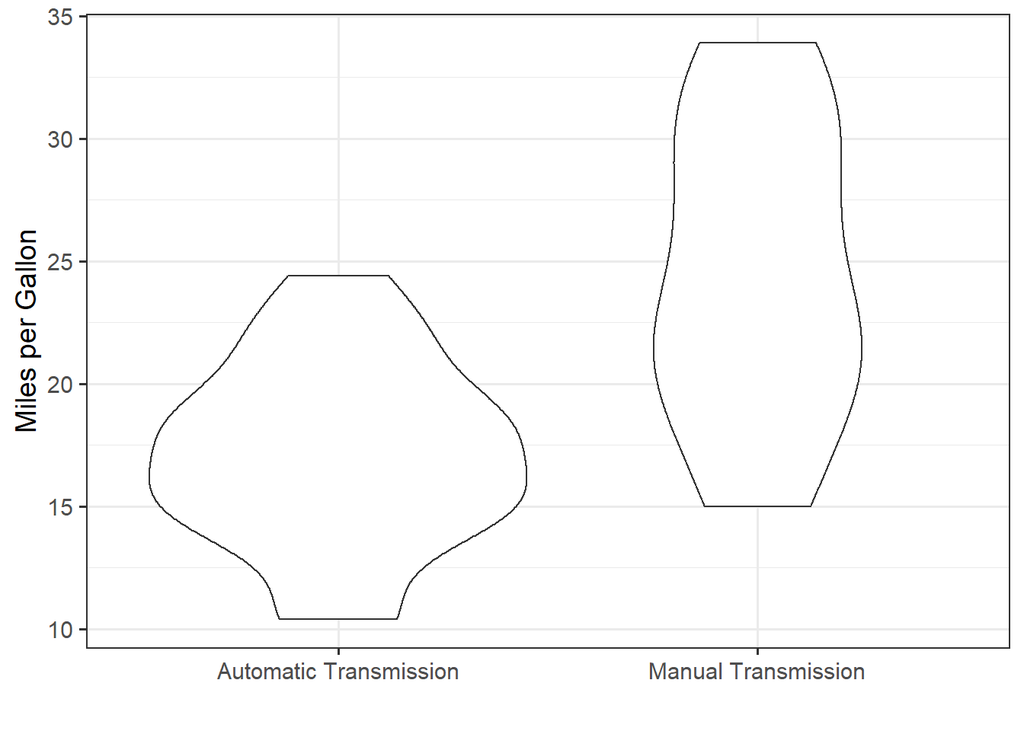

```r
ggplot(data = mtcars,
       mapping = aes(y = mpg, x = am)) +
  geom_violin() +
  labs(y = "Miles per Gallon",
       x = "")
```

## Quantitative Variable Across Groups: Individual Value Plots

When we have a small sample, boxplots are inappropriate because they hide the raw data and present an overly confident summary. Instead, we prefer to place the raw values on the plot.

1. Set the variable to be summarized on the y-axis.
2. Place the grouping variable on the x-axis.
3. Set `geom_point()`.

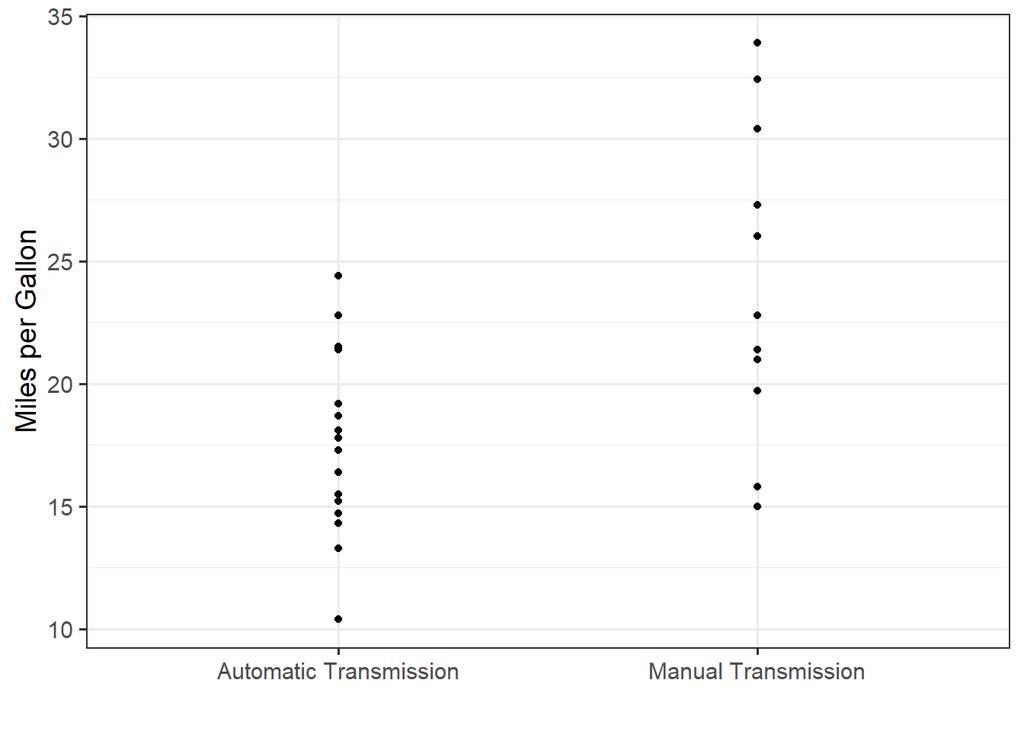

```r
ggplot(data = mtcars,
       mapping = aes(y = mpg, x = am)) +
  geom_point() +
  labs(y = "Miles per Gallon",
       x = "")
```

If it looks too overwhelming because you have just enough points that they overlap, you can “jitter” the points:

1. Set the variable to be summarized on the y-axis.
2. Place the grouping variable on the x-axis.
3. Set `geom_jitter()`.
4. Set `height = 0, width = 0.2` to prevent the data from being jittered vertically.

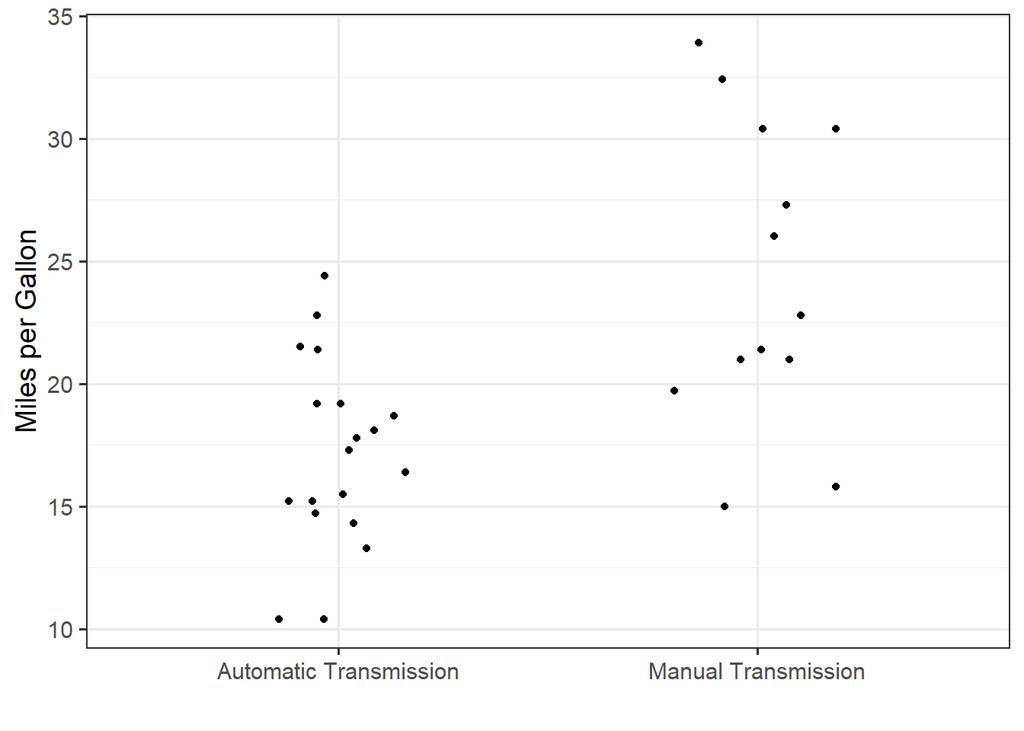

```r
ggplot(data = mtcars,
       mapping = aes(y = mpg, x = am)) +
  geom_jitter(height = 0, width = 0.2) +
  labs(y = "Miles per Gallon",
       x = "")
```

## Quantitative Variable Across Multiple Groups

Boxplots, Violin Plots, and Individual Value Plots can all be extended to include additional other groups by adding aesthetics. For example, we can construct a side-by-side boxplot which also fills according to the engine type.

1. Set variable to be summarized on the y-axis.
2. Set the primary grouping variable on the x-axis.
3. Set the secondary grouping variable as an aesthetic (`fill =`, `color =`, etc.)
4. Set `geom_boxplot()` for example.

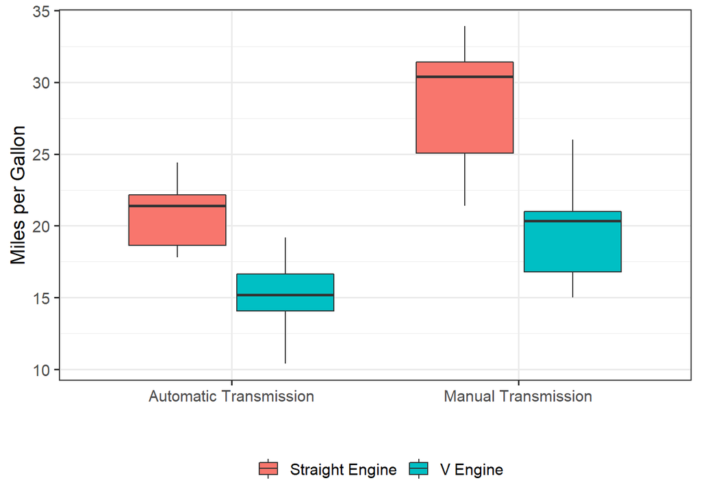

```r
ggplot(data = mtcars,
       mapping = aes(y = mpg, x = am, fill = vs)) +
  geom_boxplot() +
  labs(y = "Miles per Gallon",
       x = "",
       fill = "")
```

## Two Quantitative Variables: Scatterplot

When examining the relationship between two quantitative variables, we can use a scatterplot.

1. Set the response (variable to be explained or predicted) on the y-axis.
2. Set the predictor (the “given” information) on the x-axis.
3. Set `geom_point()`.

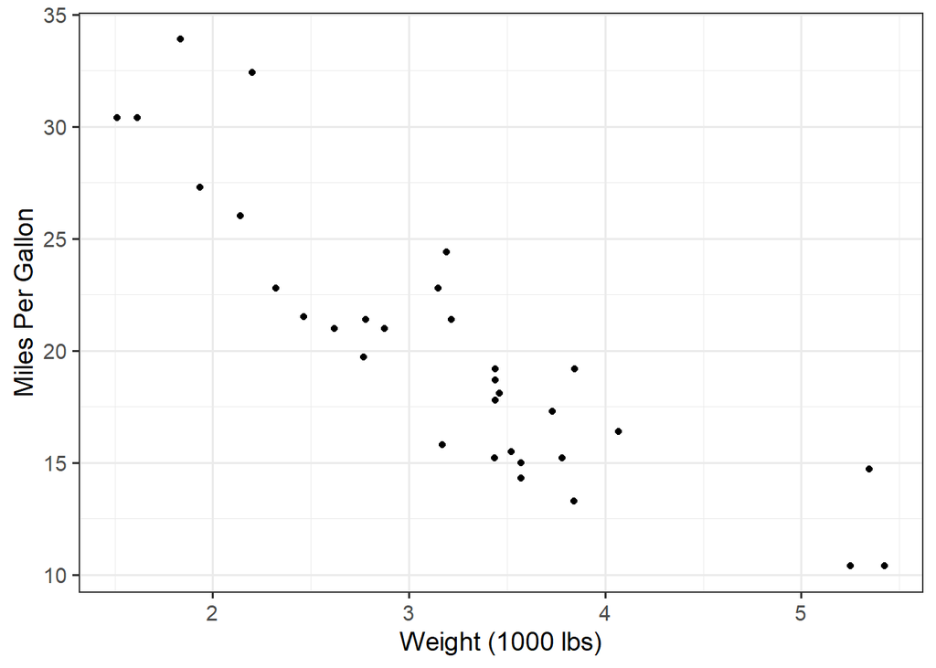

```r
ggplot(data = mtcars,
       mapping = aes(y = mpg, x = wt)) +
  geom_point() +
  labs(y = "Miles Per Gallon",
       x = "Weight (1000 lbs)")
```

## Adding Features to Scatterplots

Just as with other plots, we can add additional features to a scatterplot. In general, the following two guiding principles help when thinking about these additional aesthetics:

- Groups are best distinguished using color or shape.
- Quantitative variables are captured using color or size.

The following graphic examines the relationship between the fuel efficiency (MPG) of a vehicle and its weight, while also considering the transmission type of the vehicle. Since “transimission type” is categorical, we use the color to separate these groups.

1. Set the response (variable to be explained or predicted) on the y-axis.
2. Set the predictor (the “given” information) on the x-axis.
3. Set the grouping variable using `color =`.
4. Set `geom_point()`.

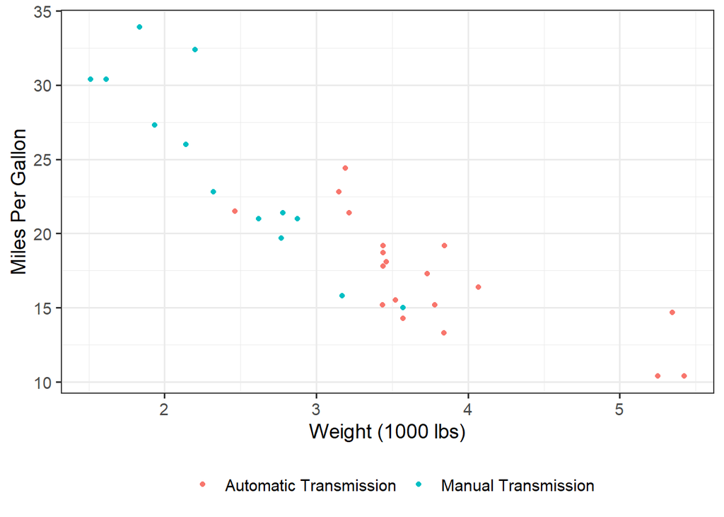

```r
ggplot(data = mtcars,
       mapping = aes(y = mpg, x = wt, color = am)) +
  geom_point() +
  labs(y = "Miles Per Gallon",
       x = "Weight (1000 lbs)",
       color = "")
```

We could also have used shape of the points instead.

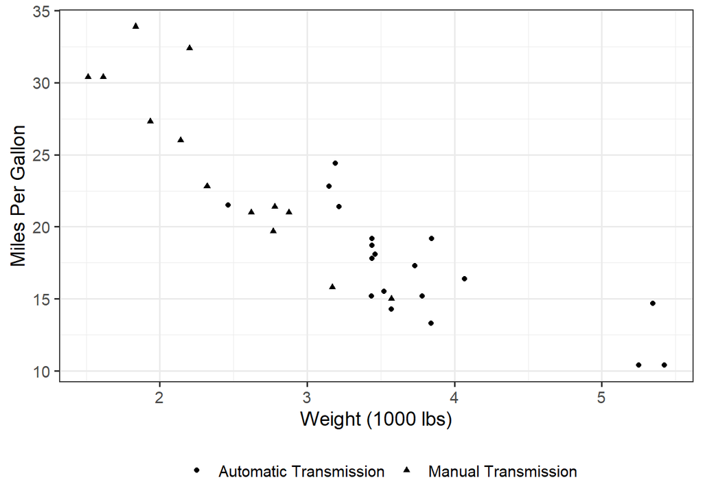

```r
ggplot(data = mtcars,
       mapping = aes(y = mpg, x = wt, shape = am)) +
  geom_point() +
  labs(y = "Miles Per Gallon",
       x = "Weight (1000 lbs)",
       shape = "")
```

If we want to look at the relationship between the fuel efficiency (MPG) of a vehicle and its weight, while also considering its horsepower, we do things a bit differently. Since “horsepower” is quantitative, we can use color or size to distinguish between various values. Both versions are shown below.

1. Set the response (variable to be explained or predicted) on the y-axis.
2. Set the predictor (the “given” information) on the x-axis.
3. Set the secondary predictor using `color =`.
4. Set `geom_point()`.

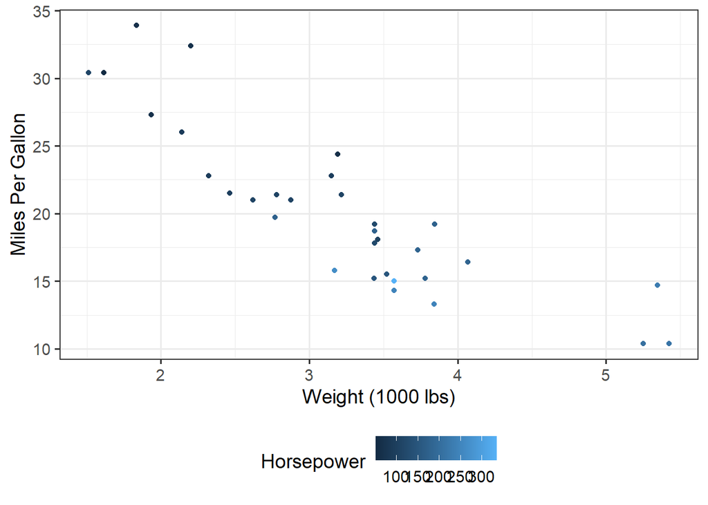

```r
ggplot(data = mtcars,
       mapping = aes(y = mpg, x = wt, color = hp)) +
  geom_point() +
  labs(y = "Miles Per Gallon",
       x = "Weight (1000 lbs)",
       color = "Horsepower")
```

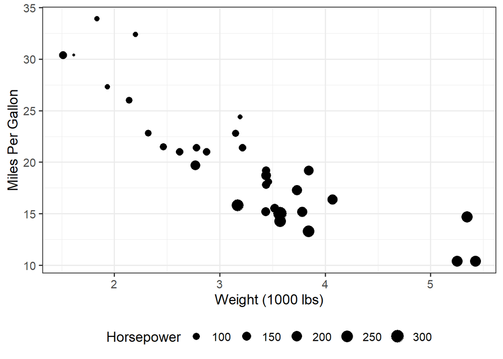

```r
ggplot(data = mtcars,
       mapping = aes(y = mpg, x = wt, size = hp)) +
  geom_point() +
  labs(y = "Miles Per Gallon",
       x = "Weight (1000 lbs)",
       size = "Horsepower")
```

## Plotting a Smooth Function

Occasionally, we want to plot a smooth function over an interval. Generally, these smooth functions are already encoded in R; for example, suppose we want to plot the sine function over the interval 0 to $2\pi$. The sine function in R is controlled through `sin()`. The plot is constructed by setting an empty graphic and adding layers that control the interval over which to plot as well as the function to construct.

1. The `ggplot()` call should be empty.
2. Add the interval over which to plot using `xlim(lower, upper)`, where the first value provided is the lower limit and the second value is the upper limit.
3. Use `geom_function(fun = , additional arguments)` to provide the name of the function to plot, as well as any additional arguments necessary for the function.

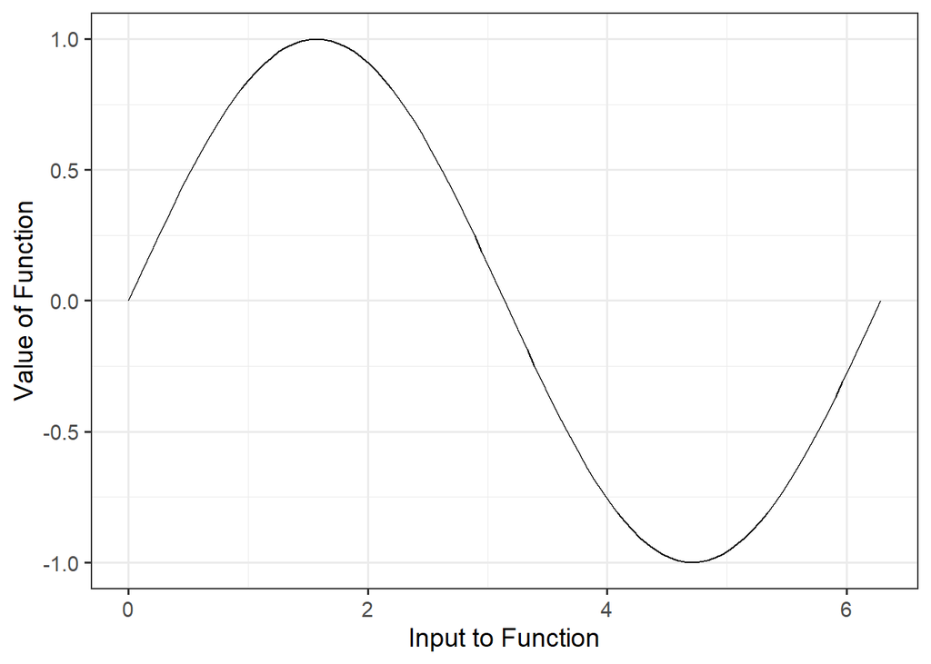

```r
ggplot() +
  xlim(0, 2*pi) +
  geom_function(fun = sin) +
  labs(y = "Value of Function",
       x = "Input to Function")
```

This is particularly useful if you want to overlay a function onto a graphic. In such cases, the `ggplot()` function would no longer be empty and additional layers placing the raw data on the graphic would be included.

# Essential Probability

Suppose we have a random variable $X$ which follows some *known* distribution. When computing a p-value, we generally compute probabilities of the form

$$Pr(X > q) = 1 - Pr(X \leq q) = 1 - F(q)$$

for some known value $q$; that is, we need to evaluate the cumulative distribution function (CDF) of the random variable. When computing a confidence interval, we are interested in the value $q$ such that

$$1 - \alpha = Pr(X \leq q)$$

for some known value $0 < \alpha < 1$. That is, we need the *inverse* of the CDF. The following table provides the associated functions for common distributions, along with the name of the arguments that defines the parameters governing these functions.

| Distribution | CDF | Inverse CDF | Parameters |
| --- | --- | --- | --- |
| Normal | `pnorm` | `qnorm` | mean, standard deviation (`mean`, `sd`) |
| Chi-Square | `pchisq` | `qchisq` | degrees of freedom (`df`) |
| t | `pt` | `qt` | degrees of freedom (`df`) |
| F | `pf` | `qf` | numerator and denominator degrees of freedom (`df1`, `df2`) |

As an example, suppose we have that $X \sim t_{29}$; we want to know $Pr(X > 2.67$:

```r
1 - pt(2.67, df = 29)
```

```
[1] 0.006149683
```

In contrast, if we want the 97.5-th percentile from a $N(0, 1)$ distribution, we have

```r
qnorm(0.975, mean = 0, sd = 1)
```

```
[1] 1.959964
```

# Basic Computations

Like any computing environment, we have access to several basic mathematical functions. Below is a table of common functions.

| Operation | Function |
| --- | --- |
| Exponential | `exp()` |
| Natural Logarithm | `log()` |
| Square Root | `sqrt()` |
| Sine | `sin()` |

# Linear Regression

## Fitting Basic Models

Consider fitting a model of the form

$$(\text{MPG})_i = \beta_0 + \beta_1(\text{Weight})_i + \varepsilon_i$$

This is fit by least squares using the `lm()` function.

- The response goes on the left-hand side, followed by a `~`.
- The intercept is included by default.
- The dataset is specified by `data =` option.
- Indicator variables for categorical predictors are created automatically.

It is a good idea to store the resulting fit for later summary.

```r
fit.mtcars <- lm(mpg ~ wt, data = mtcars)
```

The fit is summarized by the `tidy()` function.

- `conf.int = TRUE` requests confidence intervals.
- `conf.level = 0.95` specifies a 95% confidence interval for each parameter.

```r
tidy(fit.mtcars, conf.int = TRUE, conf.level = 0.95)
```

```
# A tibble: 2 x 7
  term        estimate std.error statistic  p.value conf.low conf.high
  <chr>          <dbl>     <dbl>     <dbl>    <dbl>    <dbl>     <dbl>
1 (Intercept)    37.3      1.88      19.9  8.24e-19    33.5      41.1
2 wt             -5.34     0.559     -9.56 1.29e-10    -6.49     -4.20
```

## Summarizing the Model Fit (R-Squared)

The model fit can be summarized with the `glance()` function.

```r
glance(fit.mtcars)
```

```
# A tibble: 1 x 12
  r.squared adj.r.squared sigma statistic  p.value    df logLik   AIC   BIC
      <dbl>         <dbl> <dbl>     <dbl>    <dbl> <dbl>  <dbl> <dbl> <dbl>
1     0.753         0.745  3.05      91.4 1.29e-10     1  -80.0  166.  170.
# ... with 3 more variables: deviance <dbl>, df.residual <int>, nobs <int>
```

## Computing Residuals

Diagnostic graphics used to assess conditions on the stochastic portion of the model depend on residuals and fitted values. In order to obtain the residuals, we augment the original data based on the model constructed using the `augment()` function. These results must be stored in a dataset. This function cannot be used until you first specify a model so that residuals can be computed.

1. First argument is the model fit (from the full model under the alternative hypothesis if comparing two models).
2. Second argument is the dataset we want to add to (if not included, diagnostic values are added to the data used to fit the model).

```r
mtcars.augment <- augment(fit.mtcars)
```

The result is actually a new dataset which includes various new variables (beginning with period in the name) used to assess a model fit. The variable `.resid` contains the residuals, and the variable `.fitted` contains the fitted values or predicted values. The first few records of this new dataset are shown below:

| .rownames | mpg | wt | .fitted | .resid | .hat | .sigma | .cooksd | .std.resid |
| --- | --- | --- | --- | --- | --- | --- | --- | --- |
| Datsun 710 | 22.8 | 2.320 | 24.886 | -2.086 | 0.058 | 3.072 | 0.015 | -0.706 |
| Merc 240D | 24.4 | 3.190 | 20.236 | 4.164 | 0.031 | 2.997 | 0.031 | 1.389 |
| Merc 230 | 22.8 | 3.150 | 20.450 | 2.350 | 0.031 | 3.066 | 0.010 | 0.784 |
| Fiat 128 | 32.4 | 2.200 | 25.527 | 6.873 | 0.066 | 2.802 | 0.193 | 2.335 |
| Honda Civic | 30.4 | 1.615 | 28.654 | 1.746 | 0.118 | 3.079 | 0.025 | 0.610 |
| Toyota Corolla | 33.9 | 1.835 | 27.478 | 6.422 | 0.096 | 2.833 | 0.260 | 2.217 |

## Diagnostic Plots: Time-Series Plot

If the data is recorded in the order in which it was collected, we can construct a time-series plot of the residuals.

1. Use the augmented dataset (see above) that contains the residuals.
2. Set `y = .resid`.
3. Set `x = seq_along(.resid)` to construct the order of the observations.
4. Use both `geom_line()` and `geom_point()` to connect the dots.

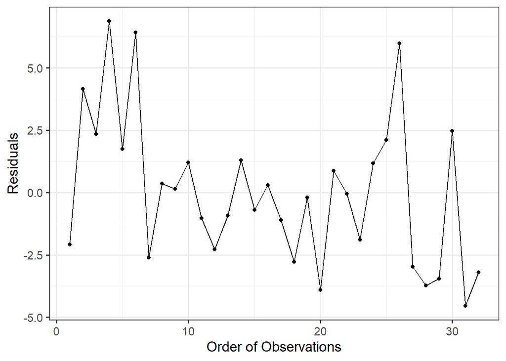

```r
ggplot(data = mtcars.augment,
       mapping = aes(y = .resid, x = seq_along(.resid))) +
  geom_point() +
  geom_line() +
  labs(y = "Residuals",
       x = "Order of Observations")
```

The nice thing about this graphic is that the only thing that changes is the dataset from which to pull the residuals.

## Diagnostic Plots: Residual vs. Fitted Values

A plot of the residuals against the fitted values can be helpful for assessing various conditions.

1. Use the augmented dataset (see above) that contains the residuals.
2. Set `y = .resid`.
3. Set `x = .fitted`.
4. Set `geom_point()`.

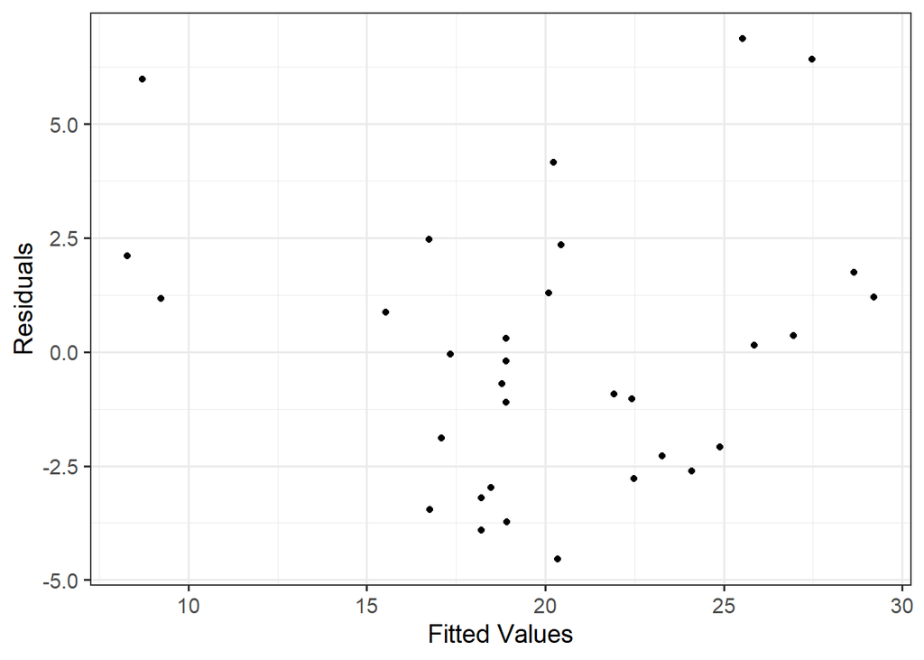

```r
ggplot(data = mtcars.augment,
       mapping = aes(y = .resid, x = .fitted)) +
  geom_point() +
  labs(y = "Residuals",
       x = "Fitted Values")
```

It can sometimes be helpful to include a smoother on this graphic. This can be done easily by adding the `geom_smooth()` layer.

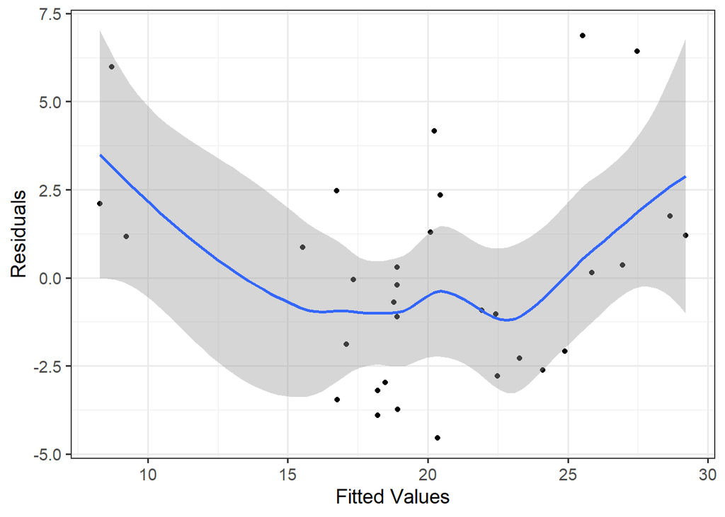

```r
ggplot(data = mtcars.augment,
       mapping = aes(y = .resid, x = .fitted)) +
  geom_point() +
  geom_smooth() +
  labs(y = "Residuals",
       x = "Fitted Values")
```

## Diagnostic Plots: Probability Plot

A probability plot, or quanitile-quantile plot (QQ-plot for short) can also be made of the residuals.

1. Use the augmented dataset (see above) that contains the residuals.
2. Set `sample = .resid`.
3. Set `stat_qq()` and `stat_qq_line()`.

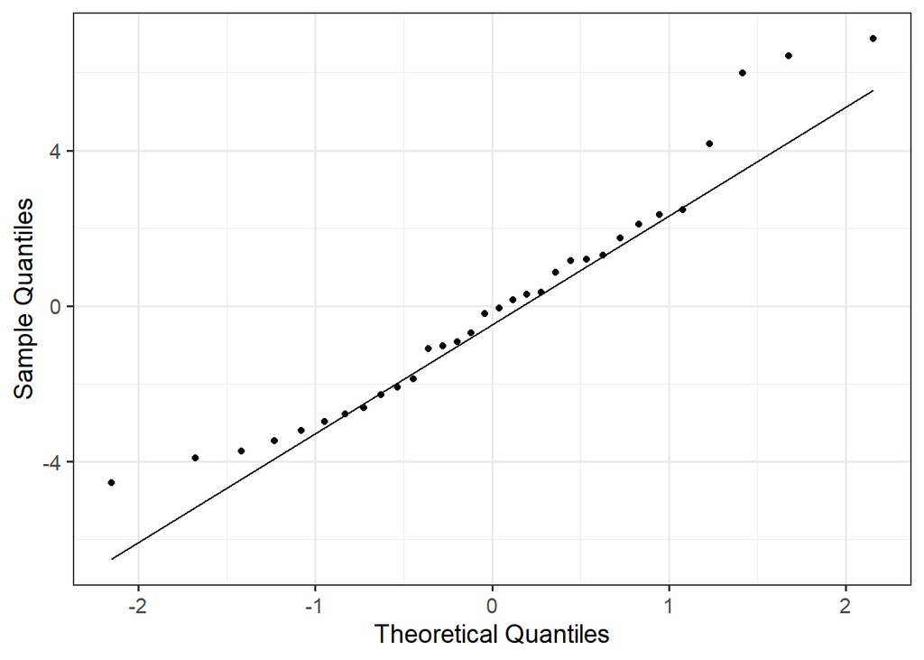

```r
ggplot(data = mtcars.augment,
       mapping = aes(sample = .resid)) +
  stat_qq() +
  stat_qq_line() +
  labs(y = "Sample Quantiles",
       x = "Theoretical Quantiles")
```

## Estimating the Mean Response

Consider our model for allowing the mean fuel efficiency to depend upon the weight of the vehicle. Suppose we are interested in estimating the fuel efficiency for a vehicle which weighs 2000 pounds and one which weighs 3000 pounds (keeping in mind that `wt` is specified in 1000’s of pounds). We are essentially interested in plugging into the model. This is similar to constructing fitted values; so, it should not be a surprise that we use the `augment` function. However, we must first create the data describing the values we want to predict.

```r
Predict_data <- tibble(
  wt = c(2, 3)
)
```

Notice that this dataset has the variable named exactly as it appears in our original model. Now, we use the augment function.

```r
augment(fit.mtcars, newdata = Predict_data)
```

```
# A tibble: 2 x 2
     wt .fitted
  <dbl>   <dbl>
1     2    26.6
2     3    21.3
```

The resulting dataset has the estimated predicted values, but it does not contain a confidence interval for the average response. We can also request this (the default being a 95% CI).

```r
augment(fit.mtcars, newdata = Predict_data, interval = "confidence")
```

```
# A tibble: 2 x 4
     wt .fitted .lower .upper
  <dbl>   <dbl>  <dbl>  <dbl>
1     2    26.6   24.8   28.4
2     3    21.3   20.1   22.4
```

# Bootstrapping in Linear Models

Statistics is all about quantifying the variability in our estimates. Inference is performed by modeling the distribution of those estimates (or some standardized function of them). This can be done by imposing conditions on the data generating process. With enough conditions, we can often model the distribution of the statistics using probability theory. Bootstrapping is a method of modeling the variability in the statistics when we are not willing to impose the classical conditions on a model for the data generating process.

In this course, we will implement bootstrapping through the `lmboot` package, authored by Dr. Heyman.

## Residual Bootstrap in Linear Models

In a regression model, a residual bootstrap is conducted using the `residual.boot()` function. This function is very similar to the `lm()` function. The additional syntax includes the following:

- `B`: the number of bootstrap replicates to perform; for smaller datasets, setting this to be between 5000 and 10000 is reasonable. If you have an extremely large dataset, you may want to lower this value.
- `seed`: this value controls the random resampling; set this if you want results that are the same each time you run the code.

Consider fitting a model of the form

$$(\text{MPG})_i = \beta_0 + \beta_1(\text{Weight})_i + \varepsilon_i$$

We can perform a residual bootstrap (and save the results) using the following code:

```r
resid1 <- residual.boot(mpg ~ wt, data = mtcars, B = 10000)
```

## Wild Bootstrap in Linear Models

In a regression model, a wild bootstrap is conducted using the `wild.boot()` function. This function is very similar to the `lm()` function. The additional syntax includes the following:

- `B`: the number of bootstrap replicates to perform; for smaller datasets, setting this to be between 5000 and 10000 is reasonable. If you have an extremely large dataset, you may want to lower this value.
- `seed`: this value controls the random resampling; set this if you want results that are the same each time you run the code.

Consider fitting a model of the form

$$(\text{MPG})_i = \beta_0 + \beta_1(\text{Weight})_i + \varepsilon_i$$

We can perform a wild bootstrap (and save the results) using the following code:

```r
wild1 <- wild.boot(mpg ~ wt, data = mtcars, B = 10000)
```

## Compute Confidence Intervals

Once you have performed a bootstrap (whether residual or wild), you can compute a confidence interval by computing the corresponding percentiles from the distribution. A 95% CI, for example, requires computing the 2.5-th and 97.5-th percentiles.

To facilitate this, we will use a course-specific function called `ci_lmboot()` for computing confidence intervals. This function takes the result of *either* `residual.boot()` or `wild.boot()`. Note in addition to the bootstrap results, you specify

- `level`: the confidence level (default is 0.95 for 95% confidence intervals).

```r
ci_lmboot(resid1, level = 0.95)
```

```
# A tibble: 2 x 3
  term        conf.low conf.high
  <chr>          <dbl>     <dbl>
1 (Intercept)    33.8      40.9
2 wt             -6.38     -4.28
```

## Summarizing Bootstrap Sampling Distribution

The bootstrap sampling distribution (the distribution of the parameter estimates across the bootstrap resamples) contains lots of information. We can summarize this distribution (for *either* `residual.boot()` or `wild.boot()` results) using the `summarise_lmboot()` function.

```r
summarise_lmboot(resid1)
```

```
# A tibble: 2 x 7
  term          Min Median  Mean   Max   IQR StdErr
  <chr>       <dbl>  <dbl> <dbl> <dbl> <dbl>  <dbl>
1 (Intercept) 31.1   37.3  37.3  44.5  2.40   1.80
2 wt          -7.41  -5.36 -5.35 -3.44 0.725  0.537
```

One of the most important components of this output is the `StdErr` variable, which estimates the standard error of the parameter estimate. The `Mean` or `Median` could act as the point estimate, though we generally report the original estimate from the sample (which should align closely with the `Mean`).

## Visualizing Bootstrap Sampling Distribution

Sometimes, it can be helpful to examine the bootstrap sampling distribution (the distribution of the parameter estimates across the bootstrap resamples). This can be done for *either* `residual.boot()` or `wild.boot()` results using the `plot_lmboot()` function.

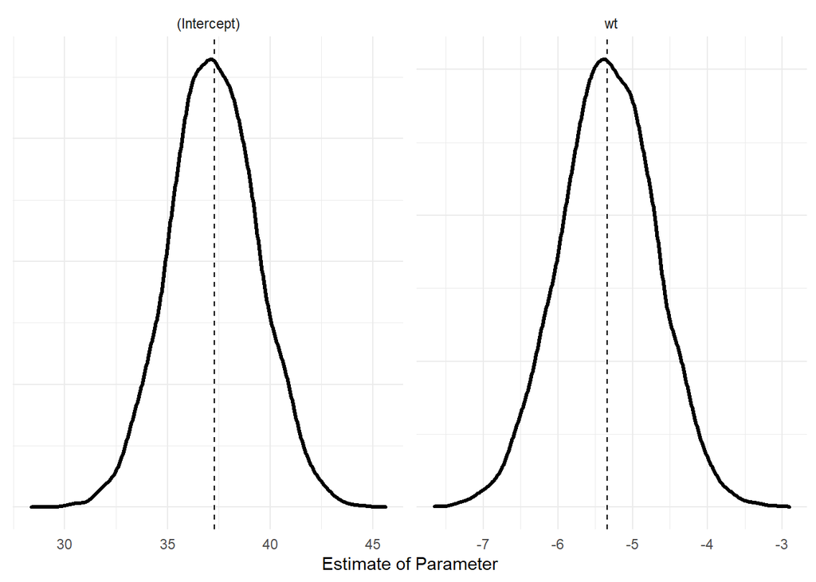

```r
plot_lmboot(wild1)
```

The returned graphic is quite simplistic. It is a `ggplot` object; so, if you would prefer to add additional elements, you can do that as if this were any other graphic in the class.

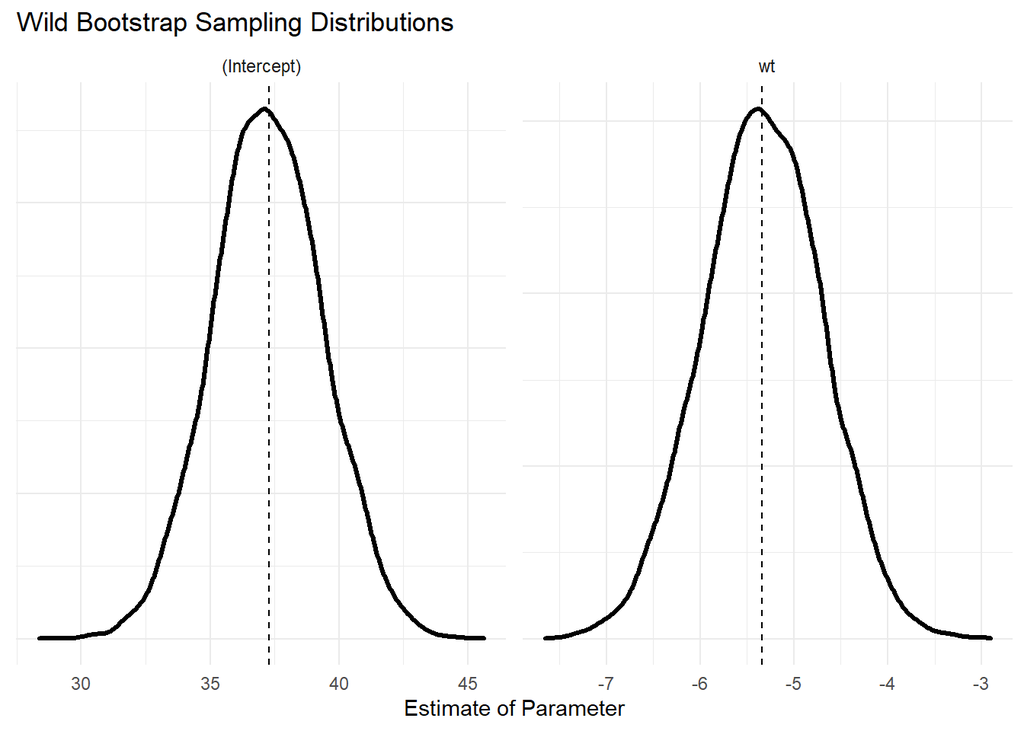

```r
plot_lmboot(wild1) +
  labs(title = "Wild Bootstrap Sampling Distributions")
```

# One-Way ANOVA Models

ANOVA models are extensions of regression models which compare a quantitative response across the levels of a categorical variable. For our purposes, consider comparing the efficiency of vehicles with an automatic transmission to those with a manual transmission. Note that while this only has two groups (manual vs. automatic), the model easily extends to $k > 2$ levels in the factor. Our model has the following form:

$$(\text{MPG})_i &= \mu_1 + \beta_1 (\text{Manual})_i + \varepsilon_i$$

where

$$(\text{Manual})_i = \begin{cases} 1 & \text{i-th vehicle has a manual transmission} \\ 0 & \text{otherwise} \end{cases}$$

is the indicator variable.

## Fitting the Model

The ANOVA model is an extension of the linear model; as a result, we fit the model using the `lm()` function just as we would if the predictor were a quantitative variable.

```r
anova_model <- lm(mpg ~ am, data = mtcars)
```

The estimates of the parameters in the model can be viewed using the `tidy()` function and an overview of the model summarized using the `glance()` function.

```r
tidy(anova_model)
```

```
# A tibble: 2 x 5
  term                  estimate std.error statistic  p.value
  <chr>                    <dbl>     <dbl>     <dbl>    <dbl>
1 (Intercept)              17.1       1.12     15.2  1.13e-15
2 amManual Transmission     7.24      1.76      4.11 2.85e- 4
```

```r
glance(anova_model)
```

```
# A tibble: 1 x 12
  r.squared adj.r.squared sigma statistic  p.value    df logLik   AIC   BIC
      <dbl>         <dbl> <dbl>     <dbl>    <dbl> <dbl>  <dbl> <dbl> <dbl>
1     0.360         0.338  4.90      16.9 0.000285     1  -95.2  196.  201.
# ... with 3 more variables: deviance <dbl>, df.residual <int>, nobs <int>
```

## Alternate Characterization

The above framework for the model is easy to fit, but the interpretation of the parameters (as an average difference from the reference group) is not as direct as we might prefer. An alternate characterization of the model would be

$$(\text{MPG})_i = \mu_1 (\text{Automatic})_i + \mu_2 (\text{Manual})_i + \varepsilon_i$$

where

$$\begin{aligned}
(\text{Manual})_i &= \begin{cases} 1 & \text{i-th vehicle has a manual transmission} \\ 0 & \text{otherwise} \end{cases} \\
(\text{Automatic})_i &= \begin{cases} 1 & \text{i-th vehicle has an automatic transmission} \\ 0 & \text{otherwise} \end{cases} \end{aligned}$$

Notice that in this model every parameter is multiplied by a variable (no parameter sits alone in the model like an intercept would). In order to fit this alternate characterization, we simply communicate to the computer to remove the “intercept” term - the parameter unattached to a variable in the model - using a `-1` in the model.

```r
alternate_anova <- lm(mpg ~ am - 1, data = mtcars)

tidy(alternate_anova)
```

```
# A tibble: 2 x 5
  term                     estimate std.error statistic  p.value
  <chr>                       <dbl>     <dbl>     <dbl>    <dbl>
1 amAutomatic Transmission     17.1      1.12      15.2 1.13e-15
2 amManual Transmission        24.4      1.36      17.9 1.38e-17
```

## Computing a P-value

For our above example comparing automatic and manual transmissions, our hypotheses of interest are

$$H_0: \mu_1 = \mu_2 \quad \text{vs.} \quad H_1: \mu_1 \neq \mu_2$$

This form of the hypothesis corresponds to the *alternate characterization* of the model discussed above. Recognize, however, that the null hypothesis (the mean responses across all the factor levels are equal) implies that there are no differences in the mean responses. That is, the following hypothesis is equivalent:

$$H_0: \beta_1 = 0 \qquad \text{vs.} \qquad H_1: \beta_1 \neq 0$$

In general, we tend to write the ANOVA hypotheses as

$$H_0: \mu_1 = \mu_2 = \dotsc = \mu_k \qquad \text{vs.} \qquad H_1: \text{At least 1 } \mu_j \text{ differs}$$

for the model

$$\begin{aligned}
(\text{Response})_i &= \mu_1 (\text{Group 1})_i + \mu_2 (\text{Group 2})_i \\
&\qquad + \dotsb + \mu_k (\text{Group } k)_i + \varepsilon_i
\end{aligned}$$

where each $(\text{Group} j)_i$ is an indicator variable.

This is equivalent to the hypotheses

$$H_0: \beta_1 = \beta_2 = \dotsc = \beta_{k-1} = 0 \quad \text{vs.} \quad H_1: \text{At least 1 } \beta_j \text{ difers from 0}$$

for the model

$$\begin{aligned}
(\text{Response})_i &= \mu_0 + \beta_1 (\text{Group 2})_i + \beta_2 (\text{Group 2})_i \\
&\qquad + \dotsb + \beta_{k-1} (\text{Group } k)_i + \varepsilon_i
\end{aligned}$$

In order to compute the p-value for this model, we do the following:

1. Fit the model *with the intercept* term.
2. Use the `anova()` function on the resulting model fit.
3. We can summarize the results using `tidy()`.

```r
anova_model <- lm(mpg ~ am, data = mtcars)

anova(anova_model) %>%
  tidy()
```

```
# A tibble: 2 x 6
  term         df sumsq meansq statistic   p.value
  <chr>     <int> <dbl>  <dbl>     <dbl>     <dbl>
1 am            1  405.  405.       16.9  0.000285
2 Residuals    30  721.   24.0      NA   NA
```

This approach makes several conditions on the error term in order to allow the null distribution of the standardized statistic to be modeled using an F-distribution.

## Assessing Conditions

We use the same diagnostic plots as for the linear model. The one exception is that as an alternative to plotting the residuals against the predicted values, we can plot the residuals against the factor of interest. Here is an example:

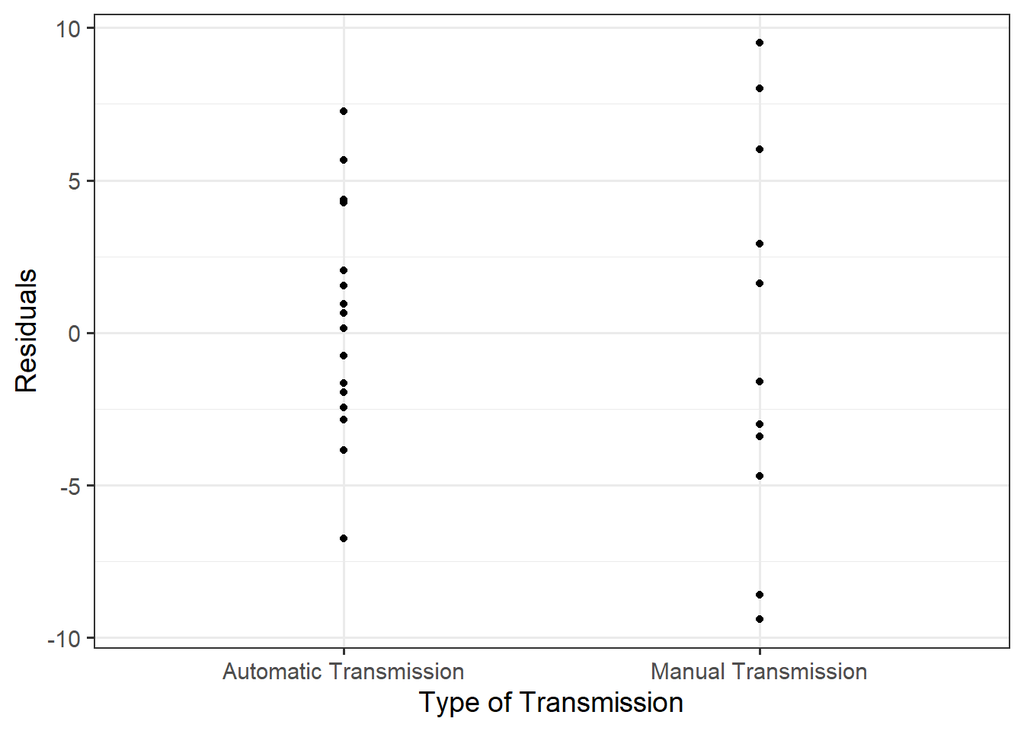

```r
mtcars_augmented <- augment(anova_model)

ggplot(data = mtcars_augmented,
       mapping = aes(y = .resid,
                     x = am)) +
  geom_point() +
  labs(y = "Residuals",
       x = "Type of Transmission")
```

# Bootstrapping for ANOVA

As with linear models, the default output from running an ANOVA in R assumes certain conditions on the errors of the data generating process. Bootstrapping is a method of modeling the null distribution of the standardized statistic when we are not willing to impose the classical conditions on a model for the data generating process.

In this course, we will implement bootstrapping through the `lmboot` package, authored by Dr. Heyman.

## Conducting the Bootstrap

For an ANOVA model, both forms of bootstrapping (residual/wild) are performed using the `ANOVA.boot()` function. This function is very similar to the `lm()` function. The additional syntax includes the following:

- `B`: the number of bootstrap replicates to perform; for smaller datasets, setting this to be between 5000 and 10000 is reasonable. If you have an extremely large dataset, you may want to lower this value.
- `seed`: this value controls the random resampling; set this if you want results that are the same each time you run the code.
- `type`: either `"residual"` or `"wild"` to indicate the type of bootstrap to implement.

Other arguments are beyond the scope of the course.

Consider fitting a model of the form

$$(\text{MPG})_i &= \mu_1 + \beta_1 (\text{Manual})_i + \varepsilon_i$$

where

$$(\text{Manual})_i = \begin{cases} 1 & \text{i-th vehicle has a manual transmission} \\ 0 & \text{otherwise} \end{cases}$$

We can perform a residual bootstrap (and save the results) using the following code:

```r
resida <- ANOVA.boot(mpg ~ am, data = mtcars, B = 10000, type = "residual")
```

To perform a wild bootstrap, we simply replace `type = "residual"` with `type = "wild"`.

To facilitate examining the results, we will use a course-specific function called `anova_lmboot()`, which creates an ANOVA table with an appropriate p-value.

```r
anova_lmboot(resida)
```

```
# A tibble: 2 x 6
  term         df sumsq meansq statistic p.value
  <chr>     <dbl> <dbl>  <dbl>     <dbl>   <dbl>
1 am            1  405.  405.       16.9  0.0003
2 Residuals    30  721.   24.0      NA   NA
```

## Summarizing Bootstrap Null Distribution

The bootstrap null distribution (the distribution of the standardized statistic across the bootstrap resamples when the null hypothesis is forced to be true) contains lots of information. We can summarize this distribution using the `summarise_lmboot()` function.

```r
summarise_lmboot(resida)
```

```
# A tibble: 1 x 7
  term            Min Median  Mean   Max   IQR StdErr
  <chr>         <dbl>  <dbl> <dbl> <dbl> <dbl>  <dbl>
1 am    0.00000000231  0.464  1.07  19.3  1.26   1.59
```

This is generally not as interesting as a visual summary.

## Visualizing Bootstrap Sampling Distribution

Sometimes, it can be helpful to examine the bootstrap null distribution (the distribution of the standardized statistic across the bootstrap resamples when the null hypothesis is forced to be true). This can be done using the `plot_f_lmboot()` function.

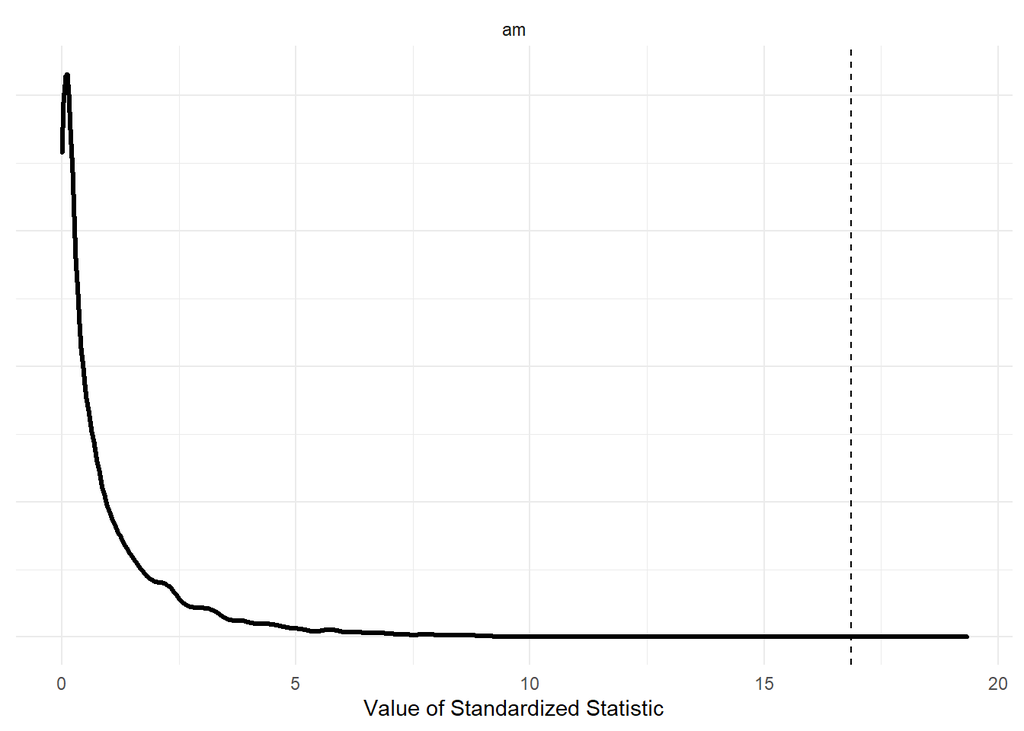

```r
plot_f_lmboot(resida)
```

As this is a `ggplot` object additional elements could be added to the graphic.

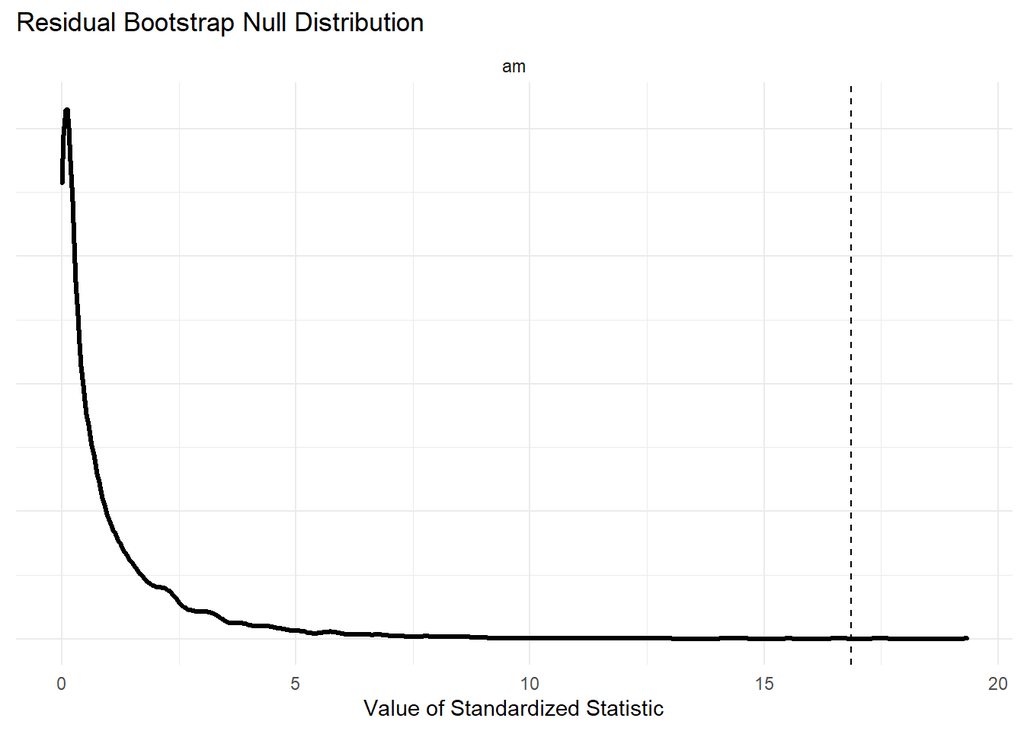

```r
plot_f_lmboot(resida) +
  labs(title = "Residual Bootstrap Null Distribution")
```

# Blocking Variables in ANOVA Models

We may sometimes be interested in comparing a quantitative response across levels of a categorical variable in the presence of a second categorical variable which introduces additional variation (known as a blocking variable).

For example, Montgomery and Runger (*Applied Statistics and Probability for Engineers and Scientists*) report on a study in which the manager of a fleet of automobiles is testing two brands of radial tires. The manager assigns one tire of each brand at random to the two rear wheels of eight cars. The car was then run until each tire required replacement (due to the tread depth being too low to be considered safe). The number of kilometers at which the tire needed replacement was recorded.

Interest is in determining if the tread life (number of kilometers at which the tire needed replacement) differs, on average between the two brands. However, it is well known that tires wear differently across different vehicles due to the construction of the vehicle itself. That is, there is a lot of variability in tire life across vehicles. Notice that the manager accounted for that in their study in that for each of the eight cars, both tires were used. The car is the *block* variable. We would like to compare the tread life, on average, between the two brands *while accounting for the additional variability across vehicles*.

This suggests the following model for the data generating process:

$$(\text{Tread Life})_i = \beta_0 + \sum_{j=2}^{8} \beta_j (\text{Car } j)_i + \gamma_1 (\text{Brand B})_i + \varepsilon_i$$

where

$$\begin{aligned}
(\text{Car } j)_i &= \begin{cases}
1 & \text{i-th observation taken from car } j \\
0 & \text{otherwise} \end{cases} \\
(\text{Brand B})_i &= \begin{cases}
1 & \text{i-th observation taken from Brand B} \\
0 & \text{otherwise} \end{cases}
\end{aligned}$$

Notice that while there is not a term for every block nor for every brand. Instead, $\gamma_1$ represents the difference, on average, between brands B and A (B minus A) for *the first block*.

## Properly Structured Data

Data should adhere to nice properties, such as each row of a dataset referring to a single observation. However, it is sometimes true, especially when the data is blocked, that scientists and engineers revert to using poor data storage practices. For example, consider the data `tires` stored in the following way:

| Car | Brand A | Brand B |
| --- | --- | --- |
| Car 1 | 36925 | 34318 |
| Car 2 | 45300 | 42280 |
| Car 3 | 36240 | 35500 |
| Car 4 | 32100 | 31950 |
| Car 5 | 37210 | 38015 |
| Car 6 | 48360 | 47800 |
| Car 7 | 38200 | 37810 |
| Car 8 | 33500 | 33215 |

In this format, each row represents two observations (one for each brand). We need to reformat the data so that each row has a single observation, with a variable for the response, the factor of interest, and the blocking term. That is, we want the data to look like the following:

| Car | Brand | Kilometers |
| --- | --- | --- |
| Car 1 | Brand A | 36925 |
| Car 1 | Brand B | 34318 |
| Car 2 | Brand A | 45300 |
| Car 2 | Brand B | 42280 |
| Car 3 | Brand A | 36240 |
| Car 3 | Brand B | 35500 |
| Car 4 | Brand A | 32100 |
| Car 4 | Brand B | 31950 |
| Car 5 | Brand A | 37210 |
| Car 5 | Brand B | 38015 |
| Car 6 | Brand A | 48360 |
| Car 6 | Brand B | 47800 |
| Car 7 | Brand A | 38200 |
| Car 7 | Brand B | 37810 |
| Car 8 | Brand A | 33500 |
| Car 8 | Brand B | 33215 |

This is known as “pivoting” the dataset to convert from a “wide” format to a “long” format, which is more suitable for analysis. This is done using the `pivot_longer()` function which has the following key arguments:

- `cols`: the names of the columns containing the response variables, the names of which form the various values of the grouping variable (usually the factor, but could be the block). Note that any column not specified here will simply be mapped accordingly (duplicated).
- `names_to`: a name (anything you want) of the variable that will eventually store the names of the columns from `cols`.
- `values_to`: a name (anything you want) of the variable that will eventually store the values from the columns you are converting.

To convert from the bad storage option to the good storage option above, we would do the following:

```r
tires <- tires %>%
  pivot_longer(cols = c("Brand A", "Brand B"),
               names_to = "Brand",
               values_to = "Kilometers")
```

## Fitting the Model

This is an extension of the ANOVA model; as a result, we fit the model using the `lm()` function just as we would ANOVA. The terms are separated by the `+` sign.

- **It is extremely important that the block term be placed first.** While this stipulation is not really important in how the model is fit, it will impact the resulting p-values reported in R. This is a result of how R does analyses.
- **It is important the data be properly structured.** See the previous subsection regarding proper data storage.

```r
block_model <- lm(Kilometers ~ Car + Brand, data = tires)
```

The estimates of the parameters in the model can be viewed using the `tidy()` function and an overview of the model summarized using the `glance()` function.

```r
tidy(block_model)
```

```
# A tibble: 9 x 5
  term         estimate std.error statistic  p.value
  <chr>           <dbl>     <dbl>     <dbl>    <dbl>
1 (Intercept)    36056.      684.    52.7   2.32e-10
2 CarCar 2        8168.      912.     8.95  4.41e- 5
3 CarCar 3         248.      912.     0.272 7.93e- 1
4 CarCar 4       -3597.      912.    -3.94  5.58e- 3
5 CarCar 5        1991.      912.     2.18  6.54e- 2
6 CarCar 6       12458.      912.    13.7   2.66e- 6
7 CarCar 7        2383.      912.     2.61  3.48e- 2
8 CarCar 8       -2264.      912.    -2.48  4.21e- 2
9 BrandBrand B    -868.      456.    -1.90  9.86e- 2
```

```r
glance(block_model)
```

```
# A tibble: 1 x 12
  r.squared adj.r.squared sigma statistic    p.value    df logLik   AIC   BIC
      <dbl>         <dbl> <dbl>     <dbl>      <dbl> <dbl>  <dbl> <dbl> <dbl>
1     0.986         0.970  912.      61.4 0.00000855     8  -125.  270.  278.
# ... with 3 more variables: deviance <dbl>, df.residual <int>, nobs <int>
```

As with ANOVA, the additional text communicates to the user the form of the indicator variable. In particular, the `CarCar 2` tells you that this indicator variable took the value 1 when the observation was from Car 2 and 0 otherwise; similarly, `BrandBrand B` tells you that the indicator variable took the value 1 when the observation was from Brand B and 0 otherwise.

Again, remember that the -868.375 is an estimate of the difference in the average tread life between brands B and A for Car 1.

## Alternate Characterization

The above framework for the model is easy to fit, but the interpretation of the parameters (as an average difference within the first block) is not as direct as we might prefer. An alternate characterization of the model would be

$$(\text{Tread Life})_i = \sum_{j=1}^{8} \beta_j (\text{Car } j)_i + \gamma_1 (\text{Brand B})_i + \varepsilon_i$$

where the indicator variables were defined previously. Notice that in this model, there is a term for every block, but not for every brand. This leads to $\gamma_1$ being the average difference between brands *across all blocks*, which is more helpful. Notice that in this model every parameter is multiplied by a variable (no parameter sits alone in the model like an intercept would). In order to fit this alternate characterization, we simply communicate to the computer to remove the “intercept” term - the parameter unattached to a variable in the model - using a `-1` in the model.

```r
alternate_block <- lm(Kilometers ~ Car + Brand - 1, data = tires)

tidy(alternate_block)
```

```
# A tibble: 9 x 5
  term         estimate std.error statistic  p.value
  <chr>           <dbl>     <dbl>     <dbl>    <dbl>
1 CarCar 1       36056.      684.     52.7  2.32e-10
2 CarCar 2       44224.      684.     64.6  5.57e-11
3 CarCar 3       36304.      684.     53.1  2.21e-10
4 CarCar 4       32459.      684.     47.4  4.83e-10
5 CarCar 5       38047.      684.     55.6  1.59e-10
6 CarCar 6       48514.      684.     70.9  2.92e-11
7 CarCar 7       38439.      684.     56.2  1.48e-10
8 CarCar 8       33792.      684.     49.4  3.65e-10
9 BrandBrand B    -868.      456.     -1.90 9.86e- 2
```

Notice the estimate for the difference is the same. *This is not an accident*! This is the result of one of the assumptions we are making about the model — the difference in the treatments is the same across blocks. So, the alternate characterization is not as helpful here as we might have thought.

Note that we do not have a characterization where we estimate the average tread life for each brand across all blocks. That would be very interesting, but in order to obtain that, we would need to make additional assumptions about the blocks when fitting the model; while it is possible, it is beyond the scope of this course.

## Computing a P-value

For our above example comparing the two brands of tires, our hypotheses of interest are

$$H_0: \gamma_1 = 0 \quad \text{vs.} \quad H_1: \gamma_1 \neq 0$$

Notice that in general, if we had several levels of a factor we were comparing, our hypothesis would take the form

$$H_0: \gamma_1 = \gamma_2 = \dotsb = \gamma_{k-1} = 0 \quad \text{vs.} \quad H_1: \text{At least 1 } \gamma_j \text{ differs from 0}$$

for the above models. Notice how similar this is to the ANOVA hypothesis. Further, notice that the hypotheses do not involve the parameters associated with the block terms.

In order to compute the p-value for this model, we do the following:

1. Fit the model *with the intercept* term.
2. Use the `anova()` function on the resulting model fit.
3. We can summarize the results using `tidy()`.

```r
anova(block_model) %>%
  tidy()
```

```
# A tibble: 3 x 6
  term         df      sumsq    meansq statistic     p.value
  <chr>     <int>      <dbl>     <dbl>     <dbl>       <dbl>
1 Car           7 405423879. 57917697.     69.6   0.00000613
2 Brand         1   3016301.  3016301.      3.62  0.0986
3 Residuals     7   5824649.   832093.     NA    NA
```

Multiple p-values are produced. *The only one of interest is that associated with the factor of interest*, in this case the `Brand` line.

This approach makes several conditions on the error term in order to allow the null distribution of the standardized statistic to be modeled using an F-distribution.

## Assessing Conditions

We use the same diagnostic plots as for the linear model. Unlike ANOVA, we cannot assume the mean 0 condition guaranteed. So, we should plot the residuals against the fitted values.

# Frequently Asked Questions

There are some things students run into a lot. Here are some common situations.

## I just want to look at my dataset; how?

The easiest way is to go to the “Environment” tab in RStudio and double-click on the name of the dataset. It will open a spread-sheet like interface for looking at your dataset.

## My variable name has spaces and R does not like it!

Variable names which have spaces in them need to be wrapped in back ticks. Technically, all variable names can be done this way, but it is a requirement when the variable name has spaces. For example, the following is allowed:

```r
mtcars = mtcars %>%
  mutate(`Miles Per Gallon` = mpg)
```

## Why does my code block not have a green arrow?

A code block should be completely separate from surrounding text. So, be sure there is a blank line both before the code block and after it. Usually, this fixes the problem.

## How can I make a caption for my graphic?

In your code chunk, include the `fig.cap` option. For example, a code chunk might look like the following:

````
```{r, fig.cap="Relationship between fuel efficiency and the horsepower of a vehicle."}
ggplot(data = mtcars
       mapping = aes(x = hp, y = mpg)) +
  geom_point() +
  labs(x = "Horse Power",
       y = "Miles per Gallon")
```
````

This block would produce the following image (notice caption below image):

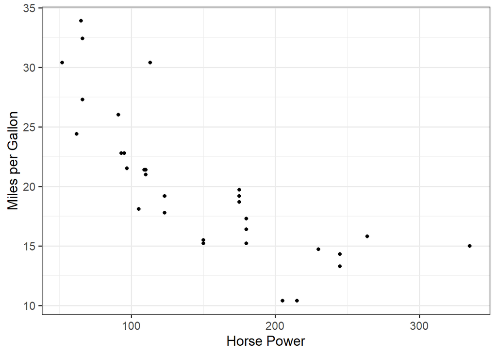

Relationship between fuel efficiency and the horsepower of a vehicle.

Another option is to add a title to graphic:

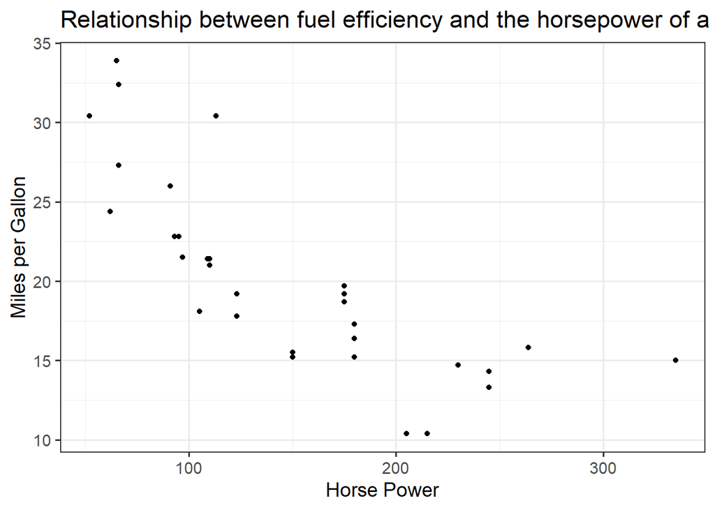

```r
ggplot(data = mtcars,
       mapping = aes(x = hp, y = mpg)) +
  geom_point() +
  labs(x = "Horse Power",
       y = "Miles per Gallon",
title = "Relationship between fuel efficiency and the horsepower of a vehicle.")
```

## R is not treating my “grouping” variable correctly!

Generally, this happens when your “grouping” variable is a number instead of a phrase. For example, in the `mtcars` dataset, the variable `cyl` takes values 4, 6, or 8. However, R does not know that these values represent groups instead of actual values. In order to get the program to recognize it as a group, rewrite the variable using `factor()`:

```r
mtcars = mtcars %>%
  mutate(cyl = factor(cyl))
```

Now, `cyl` will be treated as a grouping variable. This needs to be done only once and will work for all subsequent graphics and models constructed.

Note: you could also recode the variable manually if you wanted to:

```r
mtcars = mtcars %>%
  mutate(cyl = recode(cyl,
                      `4` = "4 Cylinder",
                      `6` = "6 Cylinder",
                      `8` = "8 Cylinder"))
```

The choice is yours.

## There are missing values.

Missing data occurs when not all observations have information on every variable in the dataset. Missing data can occur for many reasons, and it should always be investigated and understood in practice. Many functions (such as `lm()`) remove missing data automatically; however, other functions return an error. For example, consider the following simple dataset:

```r
test_data <- tibble(
  x = c(1, 2, 3, 4, 5),
  y = c(-2.25, NA, -0.76, -1.97, -0.54)
)
```

Observe that the variable `y` is missing for the second observation. This is not a problem for running a linear model:

```r
missingfit <- lm(y ~ x, data = test_data)

tidy(missingfit)
```

```
# A tibble: 2 x 5
  term        estimate std.error statistic p.value
  <chr>          <dbl>     <dbl>     <dbl>   <dbl>
1 (Intercept)   -2.43      0.966     -2.52   0.128
2 x              0.323     0.270      1.20   0.354
```

The `lm()` function simply removed all records with a missing value and then used the remaining 4 observations to fit the linear model. However, if we try to find the average of `y`:

```r
test_data %>%
  summarise(Mean_y = mean(y))
```

```
# A tibble: 1 x 1
  Mean_y
   <dbl>
1     NA
```

We see we get a missing value in return. This is trying to tell you that the sample mean cannot be computed with missing values. To remove the missing values, we can first filter the data:

```r
test_data %>%
  filter(!is.na(y)) %>%
  summarise(Mean_y = mean(y))
```

```
# A tibble: 1 x 1
  Mean_y
   <dbl>
1  -1.38
```

The `is.na()` function looks for missing values, and the `!` negates this; that is, `!is.na(y)` says “find the records where y is **not** missing.”

Alternatively, we can remove the missing values only in the computation of the statistic of interest.

```r
test_data %>%
  summarise(Mean_y = mean(y, na.rm = TRUE))
```

```
# A tibble: 1 x 1
  Mean_y
   <dbl>
1  -1.38
```

Many basic functions take the `na.rm = TRUE` option, which says to remove values which are `NA` before making the computation.